# INFORME ESTUDIO JUGADORES NHL

# INTRODUCCIÓN

## CONTEXTUALIZACIÓN DEL PROBLEMA Y ORIGEN DE LOS DATOS

El hockey sobre hielo, y en particular la National Hockey League (NHL), es uno de los deportes de equipo más rápidos, fluidos y complejos que existen. Tradicionalmente, la evaluación de los jugadores se ha basado en un sistema rígido de posiciones: Delanteros (Centros y Aleros) encargados de la ofensiva, y Defensas encargados de proteger la zona propia. Sin embargo, la reciente revolución analítica en el deporte y el aumento considerable de datos en relación a este, ha cuestionado esta simplificación.

En la pista, el impacto de un jugador va mucho más allá de su posición en la alineación. Las estadísticas modernas demuestran que existen defensas con una producción ofensiva superior a la de muchos delanteros, así como atacantes cuyo principal valor reside en la fricción física, el bloqueo de tiros y la capacidad de provocar penalizaciones. Ante esta realidad, surge un problema analítico: las etiquetas tradicionales son insuficientes para describir el verdadero rol táctico de un jugador.

Para abordar este problema, este trabajo inicialmente dispone de un conjunto de datos relacional masivo de la NHL obtenido de la plataforma Kaggle en el que se recogen datos desde la temporada 2000-01 hasta la 2019-20. A través del análisis multivariante de métricas de rendimiento promedio por partido (goles, tiros, golpes, robos, tiempo en el hielo, etc.), se buscará trascender las posiciones oficiales para encontrar patrones ocultos en el estilo de juego de los jugadores.

## INTRODUCCIÓN A LOS DATOS

El dataset inicial presenta una estructura relacional compuesta por las siguientes tablas:

**game_skater_stats** -> Las estadísticas básicas de cada skater que participó en cada partido.

**player_info** -> Información estática sobre los jugadores

**game_plays** -> Recoge las jugadas individuales que componen un partido

**game_plays_players** -> Jugadores involucrados en las jugadas individuales y papel dentro de ellas

**game_goalie_stats** -> Estadísticas básicas de cada portero que tuvo tiempo de juego en cada partido

**game_officials** -> Registro del equipo arbitral de cada partido

**game.csv** -> Registro de cada partido

**team_info** -> Información estática de los equipos

**game_teams_stats** -> Estadísticas básicas de cada equipo por partido

**game_goals** -> Goles anotados

**game_penalties** -> Penalizaciones recibidas

**game_shifts** -> Detalles sobre qué jugadores estuvieron en la pista de hielo y en qué momentos de cada partido

**game_scratches** -> Registro de jugadores convocados pero que no jugaron

A continuación se explica brevemente el significado de cada variable en las tablas seleccionadas para el objetivo de nuestro trabajo.

## TABLAS SELECCIONADAS

**GAME_SKATER_STATS**

*game_id* -> Identificador del partido

*player_id* -> Identificador del jugador

*team_id* -> Identificador del equipo

*timeOnIce* -> Tiempo total del jugador en la pista

*assists* -> Número de asistencias. En la NHL, una asistencia se otorga a los dos últimos jugadores del equipo que anota que tocaron el disco consecutivamente antes del goleador, siempre que no haya habido intercepción o posesión por parte del equipo contrario

*goals* -> Cantidad de goles marcados por el jugador en ese encuentro

*shots* -> Total de tiros a puerta realizados por el jugador

*hits* -> Número de impactos físicos o cargas legales que el jugador realizó a un rival.

*powerPlayGoals* -> Goles marcados por el jugador mientras su equipo jugaba con superioridad numérica

*powerPlayAssists* -> Asistencias repartidas por el jugador durante una superioridad numérica.

*penaltyMinutes* -> Minutos totales de castigo que el jugador tuvo que cumplir en la caja de penalizaciones por cometer infracciones

*faceOffWins* -> Cantidad de saques neutrales en los que el jugador ganó la posesión del disco

*faceoffTaken* -> Total de saques neutrales en los que el jugador participó

*takeaways* -> Número de veces que el jugador robó o recuperó activamente el disco de un rival

*giveaways* -> Número de veces que el jugador perdió la posesión del disco debido a un error no forzado

*shortHandedGoals* -> Goles marcados por el jugador mientras su equipo estaba en desventaja numérica

*shortHandedAssists* -> Asistencias dadas por el jugador estando su equipo en desventaja numérica

*blocked* -> Tiros del equipo contrario que el jugador interceptó o bloqueó

*plusMinus* -> Balance del rendimiento del equipo con el jugador en pista

*evenTimeOnIce* -> Tiempo que el jugador pasó en pista en situaciones igualdad numérica

*shortHandedTimeOnIce* -> Tiempo que el jugador pasó en pista en situaciones inferioridad numérica

*powerPlayTimeOnIce* -> Tiempo que el jugador pasó en pista en situaciones superioridad numérica

**PLAYER_INFO**

*player_id* -> Identificador del jugador

*firstName* -> Nombre

*lastName* -> Apellido

*nationality* -> Nacionalidad

*birthCity* -> Ciudad de nacimiento

*primaryPosition* -> Posición principal

*birthDate* -> Fecha de nacimiento

*birthStateProvince* -> Estado o provincia de nacimiento

*height* -> Altura

*height_cm* -> Altura en centímetros

*weight* -> Peso

*shootsCatches* -> Lateralidad del jugador (Zurdo | Diestro)

**GAME**

*game_id* -> Identificador del partido

*season* -> Temporada

*type* -> Fase de la temporada a la que corresponde el partido

*date_time_GMT* -> Fecha y hora del inicio del partido

*away_team_id* -> Identificador del equipo visitante

*home_team_id* -> Identificador del equipo local

*away_goals* -> Goles anotados por el equipo visitante

*home_goals* -> Goles anotados por el equipo local

*outcome* -> Resultado final que describe al ganador y la forma en que se decidió el partido (Tiempo regular, prórroga o penaltis)  
*home_rink_side_start* -> Lado de la pista en el que comenzó jugando el equipo local en el primer periodo

*venue* -> Nombre del pabellón

*venue_link* -> Ruta o enlace a la API de la NHL que contiene los detalles específicos de ese pabellón

*venue_time_zone_id* -> Identificador geográfico estándar de la zona horaria donde se ubica el estadio

*venue_time_zone_offset* -> Diferencia en horas respecto al tiempo universal (UTC) aplicable a la ciudad del estadio

*venue_time_zone_tz* -> Abreviatura oficial de la zona horaria local en la que se jugó el partido

**TEAM_INFO**

*team_id* -> Identificador del equipo

*franchiseId* -> Identificador histórico de la franquicia, el cual se mantiene intacto a lo largo del tiempo incluso si el equipo cambia de nombre o de ciudad

*shortName* -> Nombre corto

*teamName* -> Nombre geográfico de la ciudad, estado o provincia a la que representa la franquicia

*abbreviation* -> Abreviatura oficial de tres letras

*link* -> Ruta o enlace específico a la API de la NHL donde se encuentra almacenada la información adicional y extendida sobre el equipo

**GAME_TEAMS_STATS**

*game_id* -> Identificador del partido

*team_id* -> Identificador del equipo

*HoA* -> Indica si el equipo jugó de local o visitante

*won* -> Indica si el equipo ganó el partido (Booleana)

*settled_in* -> Indica en qué momento o fase finalizó el partido

*head_coach* -> Nombre del entrenador principal que dirigió al equipo durante ese partido

*goals* -> Número total de goles anotados por el equipo

*shots* -> Total de tiros a puerta realizados por el equipo

*hits* -> Número total de impactos o cargas físicas aplicadas por los jugadores del equipo

*pim* -> Minutos totales de penalización acumulados

*powerPlayOpportunities* -> Número de veces que el equipo tuvo ventaja numérica

*powerPlayGoals* -> Número total de goles anotados por el equipo durante situaciones de ventaja numérica

*faceOffWinPercentage* -> Porcentaje global de saques neutrales ganados

*giveaways* -> Número total de pérdidas de disco por errores no forzados

*takeaways* -> Número total de recuperaciones o robos de disco

*blocked* -> Cantidad total de tiros rivales que fueron bloqueados o interceptados

## TABLAS DESCARTADAS

**GAME_GOALS**

Se excluye por redundancia. La contabilización de los goles anotados ya está presente como una variable agregada tanto a nivel individual como a nivel colectivo en las tablas seleccionadas.

**GAME_PENALTIES**

Descartada igualmente por redundancia. Los minutos de expulsión de un jugador ya están cuantificados en la variable penaltyMinutes de la tabla de estadísticas de los jugadores.

**GAME_GOALIE_STATS**

La posición de portero tiene una naturaleza asimétrica respecto al resto de jugadores de campo y sus métricas recogidas son muy distintas. Este estudio se centra en la construcción de arquetipos para jugadores de campo (skaters).

**GAME_OFFICIALS**

Carece de total relevancia para el objetivo del estudio.

**GAME_SCRATCHES**

Al no registrar participación ni métricas de rendimiento deportivo, carecen de utilidad.

**GAME_SHIFTS**

Se rechaza porque la métrica que realmente nos interesa para evaluar el impacto a nivel de tiempo de juego de un jugador es el tiempo total acumulado. Esta variable (timeOnIce) ya viene representada en la tabla seleccionada.

**GAME_PLAYS**

Su extrema granularidad excede los objetivos iniciales de este trabajo y supone una carga computacional innecesaria. Para identificar arquetipos de jugadores mediante técnicas multivariantes,las métricas ya agregadas por partido son suficientemente robustas. Sin embargo, consideramos que recuperar esta tabla sería una excelente vía de continuación futura para realizar análisis más avanzados, como el estudio espacial del comportamiento o la evaluación técnica de las aptitudes de los jugadores sobre el hielo.

**GAME_PLAYS_PLAYERS**

Muy ligada a la anterior, se descarta pues no aporta ningún valor.

## ACOTACIÓN TEMPORAL Y SELECCIÓN DE LA MUESTRA

Para el estudio, hemos delimitado el análisis exclusivamente a la temporada regular 2018-2019. Esto lo hemos hecho en base a dos criterios. En primer lugar, asegura la independencia estadística de las observaciones, ya que, incluir múltiples temporadas generaría registros duplicados del mismo jugador en diferentes etapas de su carrera, lo cual sesgaría artificialmente la formación de clústeres al agrupar individuos consigo mismos en lugar de por estilos de juego. Además el rol de un jugador puede evolucionar a lo largo de su carrera y por consiguiente su arquetipo. Analizar una sola temporada es como sacar una fotografía fija del ecosistema de la liga, lo que hace que los arquetipos sean puros y no se mezclen con la evolución de los jugadores.

En segundo lugar, hemos elegido la temporada 2018-2019 por ser la última temporada completa y regular (82 partidos por franquicia) previa a las interrupciones debidas a la pandemia del COVID-19, las cuales provocaron calendarios incompletos y divisiones aisladas en la temporada 2019-2020. De este modo, nos aseguramos un entorno competitivo homogéneo, representativo del hockey moderno y con un volumen de partidos idéntico para todos los equipos.

## OBJETIVOS

El propósito general de este proyecto es descubrir y clasificar los perfiles de juego reales dentro de la liga, para posteriormente analizar cómo las franquicias construyen sus plantillas basándose en estos perfiles. Este propósito se desglosa en los siguientes objetivos específicos:

#### Objetivo 1: Lectura, preparación y exploración visual de los datos

Ejecutar la integración de las distintas tablas de estadísticas, seguida de una limpieza profunda para filtrar jugadores con baja participación y normalizar las métricas. Este proceso se completa con una exploración visual que permite identificar sesgos posicionales y preparar una base de datos sólida y libre de sesgos para el modelado avanzado.

#### Objetivo 2: Reducción de dimensionalidad

Aplicar el Análisis de Componentes Principales (PCA) para simplificar las múltiples variables del juego en unos pocos ejes clave que expliquen la mayor parte del rendimiento. Este paso permite eliminar información redundante y traducir estadísticas complejas en dimensiones tácticas claras y manejables para el clustering.

#### Objetivo 3: Identificación de arqutipos

Implementar técnicas de Clustering sobre las componentes principales para agrupar a los jugadores en “Arquetipos” puramente empíricos (ej. Artilleros, Defensas de Choque, Creadores de Juego), evaluando si estos coinciden o divergen de sus posiciones nominales.

#### Objetivo 4: Análisis estructural de los equipos

Extrapolar los arquetipos individuales a un nivel colectivo, agrupando los datos por equipos para analizar la composición de las plantillas. Se buscará visualizar qué proporción de cada arquetipo compone a los distintos equipos de la liga.

#### Objetivo 5: Desarrollo de una aplicación interactiva

Implementar una herramienta interactiva mediante R Shiny que permita visualizar y comparar los perfiles de los jugadores en tiempo real, facilitando la toma de decisiones en direcciones deportivas mediante la exploración dinámica de los arquetipos generados.

# 1. LECTURA, VISUALIZACION Y PREPARACIÓN DE DATOS

## CARGA E INTEGRACIÓN DE LIBRERÍAS Y TABLAS

```r
#Librerias
suppressMessages(suppressWarnings({
library(dplyr)
library(knitr)
library(ggplot2)
library(ggbiplot)
library(reshape2)
library(tidyr)
library(patchwork)
library(factoextra)
library(FactoMineR)
library(cluster)
library(hopkins)
library(forcats)
library(scales)
library(jpeg)
library(png)
library(grid)
library(readr)
}))
```

```r
suppressMessages({
games <- read_csv("datos/game.csv")
skater_stats <- read_csv("datos/game_skater_stats.csv")
player_info <- read_csv("datos/player_info.csv")
team_info <- read_csv("datos/team_info.csv")
game_goals <- read_csv("datos/game_goals.csv")
game_penalties <- read_csv("datos/game_penalties.csv")
game_plays <- read_csv("datos/game_plays.csv")
game_plays_players <- read_csv("datos/game_plays_players.csv")
game_scratches <- read_csv("datos/game_scratches.csv")
game_shifts <- read_csv("datos/game_shifts.csv")
game_skater_stats <- read_csv("datos/game_skater_stats.csv")
game_teams_stats <- read_csv("datos/game_teams_stats.csv")
skaters <- game_skater_stats
players <- player_info
teams <- team_info
})
```

Como se ha mencionado en la introducción, sólo consideramos únicamente los partidos de la temporada 2018-2019

```r
games_2019 <- games %>% filter(season == 20182019)
```

Dado que los datos están distribuidos en varias tablas, es necesario unirlas para construir un único conjunto de datos a nivel de jugador por partido.

```r
suppressWarnings({
  data <- skaters %>%
    inner_join(games_2019, by = "game_id") %>%
    inner_join(players, by = "player_id") %>%
    distinct(game_id, player_id, .keep_all = TRUE)

  data %>% head() %>% kable()
})
```

| game_id | player_id | team_id | timeOnIce | assists | goals | shots | hits | powerPlayGoals | powerPlayAssists | penaltyMinutes | faceOffWins | faceoffTaken | takeaways | giveaways | shortHandedGoals | shortHandedAssists | blocked | plusMinus | evenTimeOnIce | shortHandedTimeOnIce | powerPlayTimeOnIce | season | type | date_time_GMT | away_team_id | home_team_id | away_goals | home_goals | outcome | … |
| --- | --- | --- | --- | --- | --- | --- | --- | --- | --- | --- | --- | --- | --- | --- | --- | --- | --- | --- | --- | --- | --- | --- | --- | --- | --- | --- | --- | --- | --- | --- |
| 2018020001 | 8473507 | 8 | 1437 | 0 | 0 | 3 | 3 | 0 | 0 | 0 | 0 | 0 | 2 | 1 | 0 | 0 | 1 | -1 | 1105 | 82 | 250 | 20182019 | R | 2018-10-03 23:00:00 | 8 | 10 | 2 | 3 | home win OT | … |
| 2018020001 | 8474818 | 8 | 893 | 0 | 0 | 1 | 3 | 0 | 0 | 0 | 0 | 0 | 0 | 0 | 0 | 0 | 1 | 0 | 806 | 87 | 0 | 20182019 | R | 2018-10-03 23:00:00 | 8 | 10 | 2 | 3 | home win OT | … |
| 2018020001 | 8480829 | 8 | 905 | 1 | 0 | 2 | 0 | 0 | 1 | 0 | 1 | 7 | 0 | 0 | 0 | 0 | 0 | 0 | 753 | 0 | 152 | 20182019 | R | 2018-10-03 23:00:00 | 8 | 10 | 2 | 3 | home win OT | … |
| 2018020001 | 8474038 | 8 | 883 | 1 | 0 | 2 | 3 | 0 | 0 | 0 | 0 | 1 | 0 | 0 | 0 | 0 | 1 | 1 | 788 | 65 | 30 | 20182019 | R | 2018-10-03 23:00:00 | 8 | 10 | 2 | 3 | home win OT | … |
| 2018020001 | 8475848 | 8 | 982 | 0 | 0 | 5 | 1 | 0 | 0 | 0 | 3 | 4 | 0 | 1 | 0 | 0 | 1 | 0 | 763 | 0 | 219 | 20182019 | R | 2018-10-03 23:00:00 | 8 | 10 | 2 | 3 | home win OT | … |
| 2018020001 | 8476948 | 8 | 627 | 0 | 0 | 1 | 2 | 0 | 0 | 0 | 0 | 0 | 1 | 0 | 0 | 0 | 0 | -1 | 627 | 0 | 0 | 20182019 | R | 2018-10-03 23:00:00 | 8 | 10 | 2 | 3 | home win OT | … |

## **LIMPIEZA DE DATOS**

Antes de proceder al análisis descriptivo y multivariante, es necesario realizar una fase de limpieza de los datos con el objetivo de garantizar la calidad y fiabilidad de los resultados obtenidos.

Para empezar dicha fase, estudiamos la existencia de valores nulos en cada una de las variables.

```r
# Porcentaje de NAs por variable
na_porcentaje <- colMeans(is.na(data)) * 100

# Convertir el vector a dataframe
na_df <- data.frame(
  Variable = names(na_porcentaje),
  Porcentaje_nulos = as.numeric(na_porcentaje)) %>%
  arrange(desc(Porcentaje_nulos))
na_df %>%  kable()
```

| Variable | Porcentaje_nulos |
| --- | --- |
| birthStateProvince | 28.7615232 |
| home_rink_side_start | 3.3113260 |
| nationality | 0.0040881 |
| game_id | 0.0000000 |
| player_id | 0.0000000 |
| team_id | 0.0000000 |
| timeOnIce | 0.0000000 |
| assists | 0.0000000 |
| goals | 0.0000000 |
| shots | 0.0000000 |
| hits | 0.0000000 |
| powerPlayGoals | 0.0000000 |
| powerPlayAssists | 0.0000000 |
| penaltyMinutes | 0.0000000 |
| faceOffWins | 0.0000000 |
| faceoffTaken | 0.0000000 |
| takeaways | 0.0000000 |
| giveaways | 0.0000000 |
| shortHandedGoals | 0.0000000 |
| shortHandedAssists | 0.0000000 |
| blocked | 0.0000000 |
| plusMinus | 0.0000000 |
| evenTimeOnIce | 0.0000000 |
| shortHandedTimeOnIce | 0.0000000 |
| powerPlayTimeOnIce | 0.0000000 |
| season | 0.0000000 |
| type | 0.0000000 |
| date_time_GMT | 0.0000000 |
| away_team_id | 0.0000000 |
| home_team_id | 0.0000000 |
| away_goals | 0.0000000 |
| home_goals | 0.0000000 |
| outcome | 0.0000000 |
| venue | 0.0000000 |
| venue_link | 0.0000000 |
| venue_time_zone_id | 0.0000000 |
| venue_time_zone_offset | 0.0000000 |
| venue_time_zone_tz | 0.0000000 |
| firstName | 0.0000000 |
| lastName | 0.0000000 |
| birthCity | 0.0000000 |
| primaryPosition | 0.0000000 |
| birthDate | 0.0000000 |
| height | 0.0000000 |
| height_cm | 0.0000000 |
| weight | 0.0000000 |
| shootsCatches | 0.0000000 |

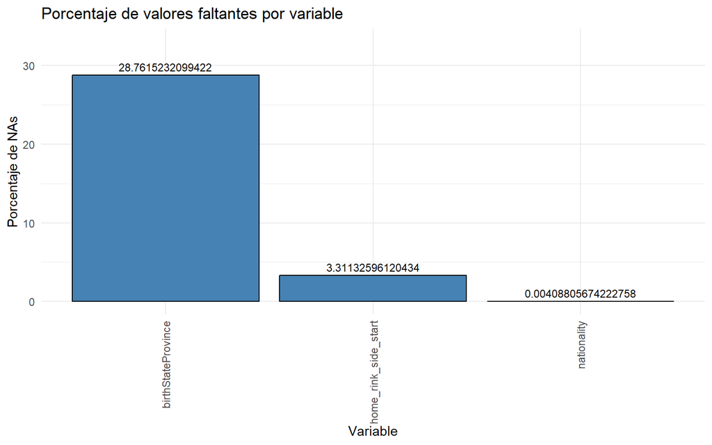

```r
na_df_filtrado <- na_df %>% filter(Porcentaje_nulos > 0)

ggplot(na_df_filtrado, aes(x = reorder(Variable, -Porcentaje_nulos), y = Porcentaje_nulos)) +
  geom_bar(stat = "identity", fill = "steelblue", color = "black") +
  geom_text(aes(label = Porcentaje_nulos), vjust = -0.5, size = 3) +
  coord_cartesian(ylim = c(0, 33)) +
  labs(title = "Porcentaje de valores faltantes por variable",
       x = "Variable",
       y = "Porcentaje de NAs") +
  theme_minimal() +
  theme(axis.text.x = element_text(angle = 90, vjust = 0.5, hjust = 1))
```

Tras el análisis de los valores faltantes en el dataset, se observa que únicamente tres variables presentan nulos: *birthStateProvince, home_rink_side_start* y *nationality*. Todas las demás variables no contienen datos perdidos y, por tanto, no requieren tratamiento adicional.

Para estas tres variables con valores ausentes, será necesario un estudio más detallado para decidir la estrategia de limpieza o imputación más adecuada, considerando la proporción de nulos y la relevancia de cada variable para los análisis posteriores.

- birthStateProvince –> Muy alta. No aporta directamente al PCA ni al clustering. Lo mejor sería eliminarla. Si más adelante se considera necesario usarla en análisis descriptivo, se deja como categoría “Desconocido”, pero para métricas de rendimiento no aporta nada.
- home_rink_side_start –> Bajo porcentaje. Se podría imputar con la moda (“Left” o “Right”) o eliminar las filas, porque solo afecta a unos pocos registros.
- nationality –> Practicamente nada. Se puede imputar con la moda de la nacionalidad (probablemente “CAN” o “USA”).

El objetivo principal es buscar arquetipos sobre los jugadores. Tras la agregación de las tablas y el filtrado de los nulos que pueden causar problemas, se obtiene una tabla que contiene datos de cada jugador en cada partido. Sin embargo, para que los arquetipos obtenidos sean estables se debe tener como filas los datos medios de cada jugador. De lo contrario, un mismo jugador con rendimientos muy distintos en partidos diferentes trastocaría el análisis.

Además, dado que el análisis posterior se centra en la identificación de patrones de rendimiento y estilo de juego mediante técnicas multivariantes, resulta necesario realizar una selección previa de variables. Para abordar simultáneamente la presencia de valores nulos y la relevancia analítica de las variables, se opta por eliminar birthStateProvince, home_rink_side_start y nationality, ya que ninguna de ellas aporta información significativa para la construcción de arquetipos de juego en la NHL.

Una vez descartadas estas tres variables, el siguiente paso consiste en identificar aquellas que, pese a no presentar valores nulos, resultan irrelevantes para describir el estilo de juego de los jugadores y, por tanto, no deben ser incluidas en el PCA. Aunque esta técnica permite reducir la dimensionalidad del conjunto de datos, su eficacia depende en gran medida de la calidad de las variables de entrada. En este sentido, la inclusión de variables no relevantes introduciría ruido en las componentes principales, dificultando la interpretación de los resultados y afectando negativamente al análisis.

- Variables identificadoras *(game_id, player_id, team_id)*: Su única función es distinguir observaciones y no aportan información relevante desde el punto de vista estadístico.
- Variables de carácter contextual asociadas al partido *(**season, type, date_time_GMT, away_team_id, home_team_id, away_goals, home_goals, outcome, venue, venue_link, venue_time_zone_id, venue_time_zone_offset, venue_time_zone_tz)*: Escriben el entorno del encuentro y no el rendimiento individual del jugador.
- Variables de carácter biográfico o descriptivo del jugador *(firstName, lastName, nationality, birthCity, birthDate, height, height_cm, weight, shootsCatches)*: Aportan información general, no reflejan directamente el estilo de juego sobre el hielo.
- Variables altamente específicas o dependientes de situaciones concretas de juego (powerPlayGoals, powerPlayAssists, shortHandedGoals, shortHandedAssists, powerPlayTimeOnIce, shortHandedTimeOnIce, evenTimeOnIce) Al ser situaciones específicas, su inclusión podría introducir sesgos asociados al rol particular del jugador dentro del equipo.

  ```r
  data_jugadores <- data %>%
    group_by(player_id, firstName, lastName, nationality, primaryPosition, birthStateProvince) %>%
    summarise(
      goals = mean(goals, na.rm = TRUE),
      assists = mean(assists, na.rm = TRUE),
      shots = mean(shots, na.rm = TRUE),
      hits = mean(hits, na.rm = TRUE),
      blocked = mean(blocked, na.rm = TRUE),
      takeaways = mean(takeaways, na.rm = TRUE),
      giveaways = mean(giveaways, na.rm = TRUE),
      penaltyMinutes = mean(penaltyMinutes, na.rm = TRUE),
      timeOnIce = mean(timeOnIce, na.rm = TRUE),
      plusMinus = mean(plusMinus, na.rm = TRUE),

      faceOffWins_total = sum(faceOffWins, na.rm = TRUE),
      faceoffTaken_total = sum(faceoffTaken, na.rm = TRUE),

      partidos_jugados = n(),
      .groups = 'drop') %>%
    filter(partidos_jugados >= 10) %>%
    arrange(player_id)

  data_jugadores %>% head(10) %>% kable()
  ```

  | player_id | firstName | lastName | nationality | primaryPosition | birthStateProvince | goals | assists | shots | hits | blocked | takeaways | giveaways | penaltyMinutes | timeOnIce | plusMinus | faceOffWins_total | faceoffTaken_total | partidos_jugados |
  | --- | --- | --- | --- | --- | --- | --- | --- | --- | --- | --- | --- | --- | --- | --- | --- | --- | --- | --- |
  | 8464989 | Matt | Cullen | USA | C | MN | 0.0933333 | 0.1733333 | 1.2000000 | 0.5066667 | 0.4400000 | 0.3200000 | 0.3333333 | 0.1866667 | 689.5867 | 0.0666667 | 341 | 678 | 75 |
  | 8465009 | Zdeno | Chara | SVK | D | NA | 0.0823529 | 0.1529412 | 1.4117647 | 1.6235294 | 1.5529412 | 0.3882353 | 0.6823529 | 0.8588235 | 1271.0706 | 0.3882353 | 0 | 0 | 85 |
  | 8466138 | Joe | Thornton | CAN | C | ON | 0.2173913 | 0.4456522 | 1.2934783 | 0.2391304 | 0.2391304 | 0.5869565 | 0.5652174 | 0.2826087 | 937.6522 | 0.0217391 | 468 | 893 | 92 |
  | 8466139 | Patrick | Marleau | CAN | C | SK | 0.1797753 | 0.2584270 | 1.8988764 | 0.9775281 | 0.4719101 | 0.3820225 | 0.2584270 | 0.3370787 | 972.7416 | -0.0561798 | 127 | 240 | 89 |
  | 8468493 | Ron | Hainsey | USA | D | CT | 0.0568182 | 0.2159091 | 1.0113636 | 1.1704545 | 1.7272727 | 0.3750000 | 0.9318182 | 0.2613636 | 1216.0000 | 0.3977273 | 1 | 1 | 88 |
  | 8468498 | Brooks | Orpik | USA | D | CA | 0.0500000 | 0.1333333 | 0.8666667 | 2.5833333 | 1.5166667 | 0.1000000 | 0.5666667 | 0.5333333 | 957.5667 | 0.1166667 | 0 | 0 | 60 |
  | 8468508 | Justin | Williams | CAN | RW | ON | 0.2783505 | 0.3402062 | 2.8865979 | 0.7422680 | 0.3711340 | 0.7422680 | 1.0103093 | 0.6391753 | 1053.0412 | -0.0309278 | 109 | 287 | 97 |
  | 8468509 | Niklas | Kronwall | SWE | D | NA | 0.0379747 | 0.3037975 | 0.8987342 | 1.0632911 | 1.2151899 | 0.1518987 | 0.7468354 | 0.5063291 | 1197.1772 | -0.0632911 | 0 | 0 | 79 |
  | 8468611 | Matt | Hendricks | USA | C | MN | 0.0000000 | 0.1153846 | 0.8846154 | 1.5384615 | 0.3076923 | 0.1923077 | 0.3846154 | 0.7307692 | 530.4231 | -0.0769231 | 42 | 77 | 26 |
  | 8468674 | Deryk | Engelland | CAN | D | AB | 0.0246914 | 0.1358025 | 1.3827160 | 2.2716049 | 2.0740741 | 0.3456790 | 0.3209877 | 0.3209877 | 1210.5185 | -0.0123457 | 0 | 0 | 81 |

```r
data_jugadores_pca <- data_jugadores %>% select(goals, assists, shots, hits, blocked, takeaways,giveaways, penaltyMinutes, timeOnIce, plusMinus)
```

Las variables faceOffWins y faceoffTaken no son especialmente informativas por separado, ya que reflejan volumen de participación. Sin embargo, su ratio proporciona una medida de eficacia en los saques de centro, siendo útil para identificar jugadores especializados en esta faceta.

```r
data_jugadores <- data_jugadores %>% mutate(faceOffRatio = ifelse(faceoffTaken_total == 0, 0, faceOffWins_total / faceoffTaken_total))
```

Al existir jugadores que no participan en saques de centro (faceoffTaken = 0), el cálculo del ratio produce una indeterminación (división por cero). Para evitar este problema, se asigna el valor 0 al ratio en estos casos. Esta decisión implica que un valor 0 puede corresponder tanto a jugadores que no participan como a jugadores con un rendimiento muy bajo. Por ello, se incluye la variable faceoffTaken, para poder distinguir entre ambos casos.

```r
data_jugadores_pca <- data_jugadores %>% select(goals, assists, shots, hits, blocked, takeaways, giveaways, penaltyMinutes, timeOnIce, plusMinus, faceOffRatio, faceoffTaken_total)
```

## EXPLORACIÓN VISUAL DE LOS DATOS

En este apartado vamos a realizar una exploración visual de los perfiles de los jugadores. Tras haber agrupado los datos para obtener una única observación por patinador basada en sus promedios por partido, estas visualizaciones nos permiten validar la estructura de nuestra información, y también nos sirven para ayudarnos a ver la problemática central de nuestro estudio: la insuficiencia de las etiquetas de posiciones oficiales para capturar la verdadera naturaleza táctica de los jugadores en la NHL.

Vemos la distribución real de las estadísticas en un partido de la NHL:

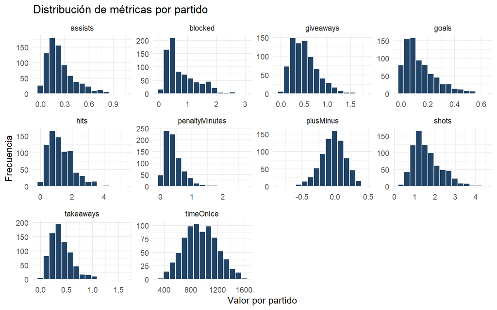

```r
#Visualizamos únicamente las estadísticas que vamos a utilizar para el PCA
data_long <- data_jugadores %>%
  select(goals, assists, shots, hits, blocked, takeaways,giveaways, penaltyMinutes, timeOnIce, plusMinus) %>%
  pivot_longer(cols = everything(), names_to = "Variable", values_to = "Valor")

ggplot(data_long, aes(x = Valor)) +
  geom_histogram(bins = 15, fill = "#214467", color = "white") +
  facet_wrap(~ Variable, scales = "free") +
  theme_minimal() +
  labs(title = "Distribución de métricas por partido",
       x = "Valor por partido",
       y = "Frecuencia")
```

Estas gráficas confirman que, al promediar las estadísticas por jugador, las distribuciones mantienen una marcada asimetría a la derecha en métricas clave como goles, asistencias y bloqueos. Este patrón refleja la especialización de la liga, donde una élite reducida concentra la mayor producción ofensiva y física. Por el contrario, variables como el balance plusMinus o el tiempo en hielo muestran una tendencia centralizada, facilitando la identificación de perfiles mediante el análisis multivariante.

Relación entre minutos jugados y tiros a puerta:

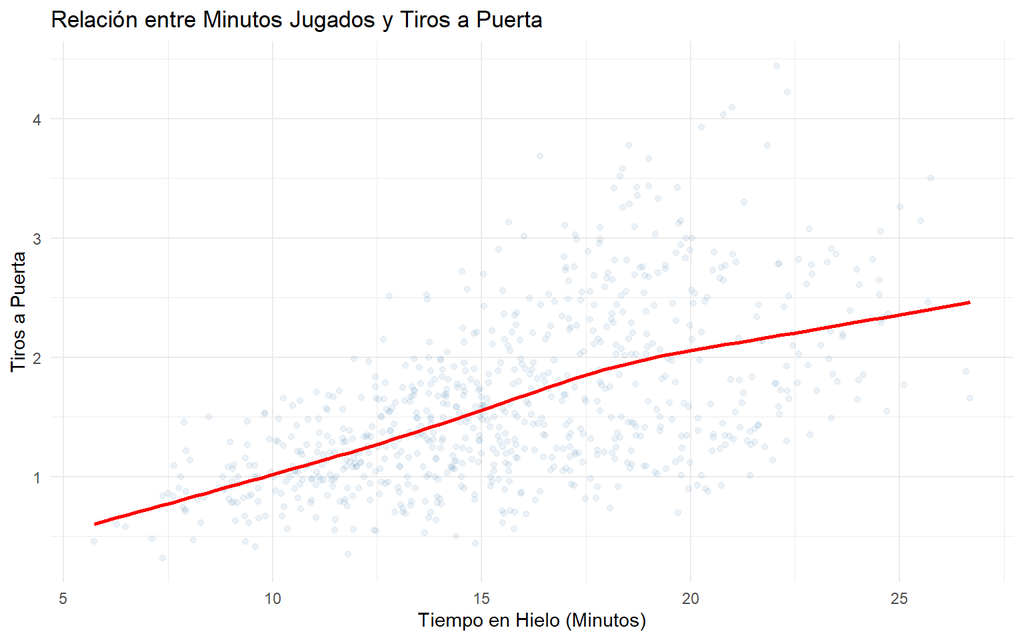

```r
suppressWarnings({
ggplot(data_jugadores, aes(x = timeOnIce / 60, y = shots)) +
  geom_point(alpha = 0.1, color = "steelblue") +
  geom_smooth(method = "gam", formula = y ~ s(x, bs = "cs"), color = "red", se = FALSE) +
  theme_minimal() +
  labs(title = "Relación entre Minutos Jugados y Tiros a Puerta",
       x = "Tiempo en Hielo (Minutos)",
       y = "Tiros a Puerta")
})
```

Este gráfico de dispersión nos muestra una correlación positiva clara entre el tiempo en pista y la ejecución de tiros a puerta. Sin embargo, observamos una gran dispersión a partir de los 15 minutos de juego que revela perfiles muy diferenciados. Existen jugadores con alta carga de minutos pero enfoque estrictamente defensivo frente a otros que disparan con alta frecuencia en menor tiempo. Esta heterogeneidad justifica el uso de técnicas multivariantes para clasificar a los jugadores según su eficiencia y rol real, más allá de su simple presencia en el hielo.

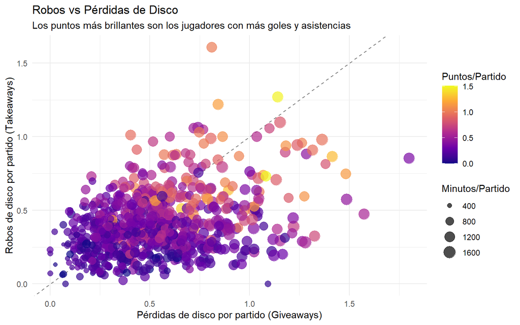

```r
#Creamos una variable de "Éxito" (Puntos totales por partido)
data_jugadores_graf <- data_jugadores %>%
  mutate(
    puntos_totales = goals + assists,
    nombre_completo = paste(firstName, lastName)
  )

ggplot(data_jugadores_graf, aes(x = giveaways, y = takeaways)) +
  geom_abline(intercept = 0, slope = 1, linetype = "dashed", color = "gray50") +
  #COLOREAMOS POR PUNTOS TOTALES (Éxito) y el tamaño por el Tiempo Jugado
  geom_point(aes(color = puntos_totales, size = timeOnIce), alpha = 0.7) +
  scale_color_viridis_c(option = "plasma", name = "Puntos/Partido") +
  theme_minimal() +
  labs(title = "Robos vs Pérdidas de Disco",
       subtitle = "Los puntos más brillantes son los jugadores con más goles y asistencias",
       x = "Pérdidas de disco por partido (Giveaways)",
       y = "Robos de disco por partido (Takeaways)",
       size = "Minutos/Partido")
```

Como se puede apreciar, los jugadores con mas puntos tienden a situarse en el cuadrante superior derecho. Este patrón confirma que las estrellas de la liga asumen el riesgo de perder el disco debido a su alta participación en el juego, pero lo compensan con una gran capacidad para recuperarlo. Esta distribución visual permite distinguir a los generadores de juego que tienen gran impacto, quienes, a pesar de sus estadísticas de pérdidas, son de los jugadores más importantes de su equipo.

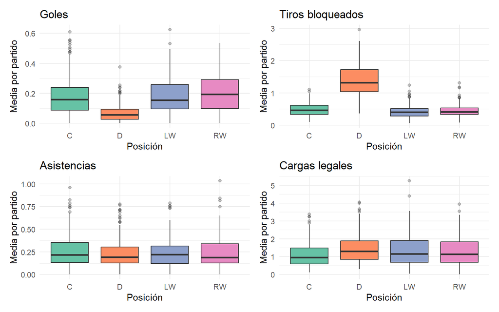

```r
# Asignamos cada gráfico a un objeto
p1 <- ggplot(data_jugadores %>% filter(primaryPosition %in% c("C", "LW", "RW", "D")),
             aes(x = primaryPosition, y = goals, fill = primaryPosition)) +
  geom_boxplot(outlier.alpha = 0.3) +
  theme_minimal() +
  scale_fill_brewer(palette = "Set2") +
  labs(title = "Goles", x = "Posición", y = "Media por partido") +
  theme(legend.position = "none")

p2 <- ggplot(data_jugadores %>% filter(primaryPosition %in% c("C", "LW", "RW", "D")),
             aes(x = primaryPosition, y = blocked, fill = primaryPosition)) +
  geom_boxplot(outlier.alpha = 0.3) +
  theme_minimal() +
  scale_fill_brewer(palette = "Set2") +
  labs(title = "Tiros bloqueados", x = "Posición", y = "Media por partido") +
  theme(legend.position = "none")

p3 <- ggplot(data_jugadores %>% filter(primaryPosition %in% c("C", "LW", "RW", "D")),
             aes(x = primaryPosition, y = assists, fill = primaryPosition)) +
  geom_boxplot(outlier.alpha = 0.3) +
  theme_minimal() +
  scale_fill_brewer(palette = "Set2") +
  labs(title = "Asistencias", x = "Posición", y = "Media por partido") +
  theme(legend.position = "none")

p4 <- ggplot(data_jugadores %>% filter(primaryPosition %in% c("C", "LW", "RW", "D")),
             aes(x = primaryPosition, y = hits, fill = primaryPosition)) +
  geom_boxplot(outlier.alpha = 0.3) +
  theme_minimal() +
  scale_fill_brewer(palette = "Set2") +
  labs(title = "Cargas legales", x = "Posición", y = "Media por partido") +
  theme(legend.position = "none")

# Creamos la matriz 2x2
(p1 | p2) / (p3 | p4)
```

Al contrastar las estadísticas de rendimiento con las posiciones oficiales, observamos resultados que refuerzan la necesidad de un análisis multivariante. En las métricas de goles y tiros bloqueados, las etiquetas tradicionales mantienen cierta coherencia lógica ya que los defensas presentan una producción goleadora inferior y un volumen de bloqueos significativamente mayor que los atacantes. Sin embargo, incluso en estos casos, la distinción desaparece al comparar a los delanteros entre sí (C, LW, RW), quienes muestran distribuciones casi idénticas independientemente de su posición concreta.

La ambigüedad es aún mayor en variables como las asistencias y las cargas legales. En estos casos, no existe una diferenciación clara ni siquiera entre defensas y atacantes. El solapamiento de los diagramas de caja es casi total. Estos confirman que, aunque la posición del jugador puede predecir comportamientos defensivos extremos, resulta insuficiente para capturar la complejidad de los roles híbridos y las especialidades técnicas de los jugadores modernos.

# 2. REDUCCIÓN DE DIMENSINALIDAD -Análisis PCA-

Tras la fase de limpieza, disponemos de un dataset con múltiples métricas que presentan una alta correlación entre sí. Es precisamente ahí donde reside la complejidad de los datos de la NHL que disponemos. Un jugador con muchos goles tiende a tener un alto volumen de disparos y tiempo en hielo. El uso directo de estas variables en un algoritmo de *clustering* podría dar unos arquetipos distorsionados. El Análisis de Componentes Principales (PCA) nos permite desglosar este ruido, transformando un conjunto de métricas redundantes en variables sintéticas (componentes) que capturan la verdadera esencia y el rol táctico de cada patinador.

```r
pca <- prcomp(data_jugadores_pca, center = TRUE, scale. = TRUE)
kable(as.data.frame(round(summary(pca)$importance, 4)))
```

|  | PC1 | PC2 | PC3 | PC4 | PC5 | PC6 | PC7 | PC8 | PC9 | PC10 | PC11 | PC12 |
| --- | --- | --- | --- | --- | --- | --- | --- | --- | --- | --- | --- | --- |
| Standard deviation | 2.0224 | 1.5981 | 1.1697 | 0.9793 | 0.8810 | 0.7231 | 0.6765 | 0.6508 | 0.5803 | 0.5124 | 0.3779 | 0.3263 |
| Proportion of Variance | 0.3408 | 0.2128 | 0.1140 | 0.0799 | 0.0647 | 0.0436 | 0.0381 | 0.0353 | 0.0281 | 0.0219 | 0.0119 | 0.0089 |
| Cumulative Proportion | 0.3408 | 0.5537 | 0.6677 | 0.7476 | 0.8123 | 0.8558 | 0.8940 | 0.9293 | 0.9574 | 0.9792 | 0.9911 | 1.0000 |

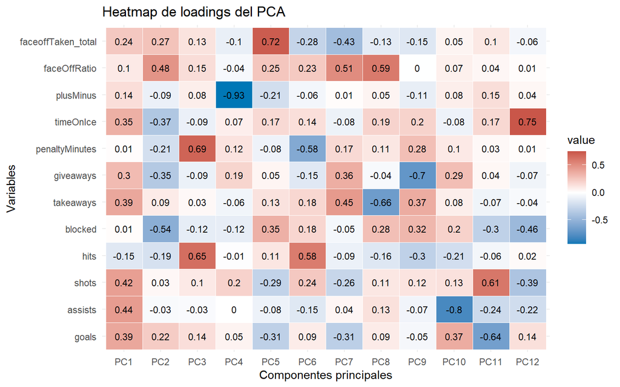

```r
loadings <- pca$rotation
loadings_melt <- melt(loadings)

ggplot(loadings_melt, aes(x = Var2, y = Var1, fill = value)) +
  geom_tile(color = "white") +
  scale_fill_gradient2(low = "#0077B6", high = "#B22222", mid = "white",
                       midpoint = 0) +
  geom_text(aes(label = round(value, 2)), size = 3) +
  theme_minimal() +
  labs(title = "Heatmap de loadings del PCA",
       x = "Componentes principales",
       y = "Variables")
```

El primer diagnóstico del PCA reveló que las variables faceOffRatio y faceoffTaken_total dominaban ciertas componentes. Dado que en el hockey profesional solo los especialistas (principalmente centros) participan en esta faceta, mantener estas métricas obligaría al modelo a agrupar a los jugadores por su posición nominal. Al eliminarlas, ‘forzamos’ al algoritmo a centrarse en el estilo de juego dinámico (físico, creación, defensa) que es aplicable a todos los patinadores, independientemente de su demarcación oficial.

```r
data_jugadores_pca2 <- data_jugadores_pca %>% select(-faceOffRatio, -faceoffTaken_total)

pca2 <- prcomp(data_jugadores_pca2, center = TRUE, scale. = TRUE)
kable(as.data.frame(summary(pca2)$importance))
```

|  | PC1 | PC2 | PC3 | PC4 | PC5 | PC6 | PC7 | PC8 | PC9 | PC10 |
| --- | --- | --- | --- | --- | --- | --- | --- | --- | --- | --- |
| Standard deviation | 1.975631 | 1.403007 | 1.147068 | 0.9772308 | 0.7220344 | 0.6813802 | 0.5888639 | 0.5158133 | 0.3888854 | 0.3286951 |
| Proportion of Variance | 0.390310 | 0.196840 | 0.131580 | 0.0955000 | 0.0521300 | 0.0464300 | 0.0346800 | 0.0266100 | 0.0151200 | 0.0108000 |
| Cumulative Proportion | 0.390310 | 0.587150 | 0.718730 | 0.8142300 | 0.8663600 | 0.9127900 | 0.9474700 | 0.9740700 | 0.9892000 | 1.0000000 |

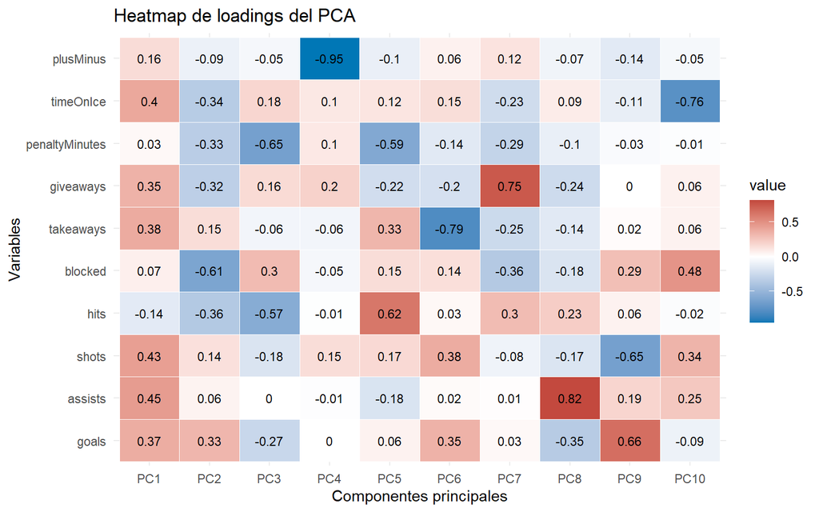

```r
loadings <- pca2$rotation
loadings_melt <- melt(loadings)

ggplot(loadings_melt, aes(x = Var2, y = Var1, fill = value)) +
  geom_tile(color = "white") +
  scale_fill_gradient2(low = "#0077B6", high = "#B22222", mid = "white",
                       midpoint = 0) +
  geom_text(aes(label = round(value, 2)), size = 3) +
  theme_minimal() +
  labs(title = "Heatmap de loadings del PCA",
       x = "Componentes principales",
       y = "Variables")
```

Ahora sí, las componentes resultantes dejan de ser simples números y pasan a representar conceptos tácticos del hockey:

- PC1: El Perfil de Estrella o Volumen (39.03%)
- PC2: El Especialista Defensivo (19.68%)
- PC3: La Agresividad Disciplinaria (13.16%)
- PC4: El Factor Eficacia (9.55%)
- PC5: El Físico Limpio (5.21%)
- PC6: El Especialista en Recuperación (4.64%)

La primera componente (PC1), que explica el 39.03% de la varianza total, actúa como un indicador de Volumen y Jerarquía. En esta dimensión, variables como las asistencias (0.45), los disparos (0.43) y el tiempo en el hielo (0.40) presentan cargas positivas elevadas. Esto significa que la PC1 define el estatus del jugador: hacia la derecha del eje encontraremos a las “estrellas” con alta participación y peligro constante, mientras que hacia la izquierda se sitúan los jugadores de rotación con un impacto estadístico más discreto.

Por su parte, la segunda componente (PC2), con un 19.68% de varianza, se consolida como el eje de Especialización Táctica. Esta dimensión polariza el juego entre el ataque y el sacrificio defensivo; un valor marcadamente negativo en esta componente está impulsado por la capacidad de bloqueo de disparos (-0.61) y la intensidad en los impactos o hits (-0.36), identificando perfiles de “muro defensivo”. En contraposición, los valores positivos se asocian a jugadores con mayor enfoque en la anotación de goles (0.33) que no priorizan las tareas de sacrificio en zona propia.

La tercera componente (PC3) captura la Agresividad y Disciplina del atleta (13.16%). Aquí, el peso recae en los minutos de penalización (-0.65) y los hits (-0.57). Es la dimensión de la “fuerza bruta”: cuanto más negativo sea el valor de un jugador en este eje, mayor es su tendencia a imponerse mediante el contacto físico y a visitar la caja de castigo.

Paralelamente, la cuarta componente (PC4) representa el Factor Eficacia (9.55%), dominada casi exclusivamente por el plusMinus (-0.95). Esta métrica funciona como un termómetro del éxito colectivo, separando a los jugadores que logran resultados positivos en el marcador durante sus turnos de aquellos que suelen estar presentes cuando el equipo encaja goles.

Finalmente, las componentes de menor varianza aportan matices de gran valor para el scouting especializado. La quinta componente (PC5) describe el Físico Limpio (5.21%), una dimensión que separa a los jugadores que emplean su físico de forma legal (altos hits, 0.62) de aquellos cuyas acciones suelen derivar en sanciones (penalizaciones negativas, -0.59). Por último, la sexta componente (PC6) se define como el Eje de Recuperación (4.64%), centrada específicamente en la lectura de juego y el robo de discos o takeaways (-0.79), permitiendo identificar a aquellos especialistas con capacidad para interceptar la posesión rival y dar inicio a transiciones ofensivas.

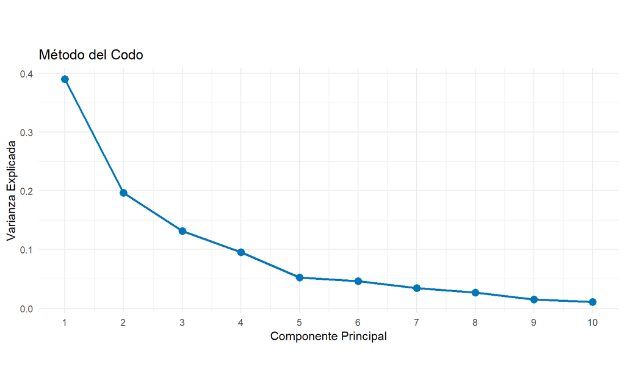

```r
# Calculamos la varianza explicada por cada componente
suppressWarnings({
ve <- pca2$sdev^2
porcentaje_ve <- ve / sum(ve)

datos_codo <- data.frame(
  PC = 1:10,
  Varianza = porcentaje_ve)

ggplot(datos_codo, aes(PC, Varianza)) +
  geom_line(size = 1, color = "#0077B6") +
  geom_point(size = 3, color = "#0077B6") +
  scale_x_continuous(breaks = 1:10) +
  labs(title = "Método del Codo",
       x = "Componente Principal",
       y = "Varianza Explicada") +
  theme_minimal() +
  coord_fixed(ratio = 10)
})
```

Aunque el análisis factorial constituye una alternativa para la reducción de dimensionalidad, en este estudio se ha optado por el uso de PCA, ya que permite una representación más directa de la variabilidad de los datos y resulta más adecuado como paso previo a técnicas de clustering.

# 3. IDENTIFICACIÓN DE ARQUETIPOS DE JUGADORES -Análisis Clusters-

## ESTUDIO DE LA TENDENCIA

Antes de aplicar un método de clustering a los datos es conveniente evaluar si hay indicios de que realmente existe algún tipo de agrupación en ellos. Vamos a aplicar el estadistico de Hopkins para ver si es adecuado realizar o no dicho análisis cluster.

```r
datos_para_clustering <- pca2$x[, 1:4]
set.seed(321)
hopkins(datos_para_clustering) %>% kable(col.names = "Índice de Hopkins", align = "c")
```

| Índice de Hopkins |
| --- |
| 0.9566809 |

Como el valor obtenido es muy cercano a 1, existen evidencias a favor de que existen agrupaciones en los datos y de que los grupos resultantes serán reales. Ahora vamos a realizar un análisis visual de los datos.

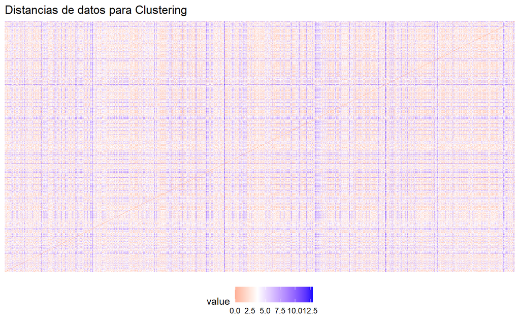

```r
dist_datos_clustering <- dist(datos_para_clustering, method = 'euclidean')
fviz_dist(dist.obj = dist_datos_clustering, show_labels = FALSE) + labs(title = "Distancias de datos para Clustering") +
    theme(legend.position = "bottom")
```

Aunque hay muchos datos, se pueden distinguir lineas verticales y horizontales, creando estructuras rectangulares. Esto respalda los resultados obtenidos con el estadístico de Hopkins.

Una vez hemos visto que el método de clustering se puede aplicar con sentido, vamos a comparar los métodos de K-means, PAM y CLARA. Como hemos obtenido una varianza acumulada del 81,42% con 4 componentes principales, vamos a realizar los clusters en el espacio que ya explica dicha varianza de los jugadores.

## ANÁLISIS Y COMPARACIÓN DE MÉTODOS DE CLUSTERING

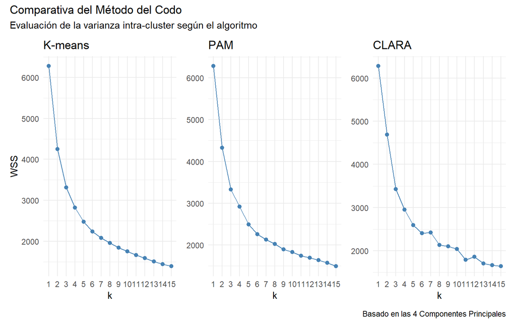

```r
p_km <- fviz_nbclust(x = datos_para_clustering, FUNcluster = kmeans, method = "wss",
                     k.max = 15, diss = get_dist(datos_para_clustering, method = "euclidean"), nstart = 50) +
        labs(title = "K-means", x = "k", y = "WSS") +
        theme_minimal()

p_pam <- fviz_nbclust(x = datos_para_clustering, FUNcluster = pam, method = "wss",
                      k.max = 15, diss = get_dist(datos_para_clustering, method = "euclidean")) +
         labs(title = "PAM", x = "k", y = NULL) + # Quitamos y para no repetir
         theme_minimal()

p_clara <- fviz_nbclust(x = datos_para_clustering, FUNcluster = clara, method = "wss",
                        k.max = 15, diss = get_dist(datos_para_clustering, method = "euclidean")) +
           labs(title = "CLARA", x = "k", y = NULL) + # Quitamos y para no repetir
           theme_minimal()

(p_km | p_pam | p_clara) +
  plot_annotation(title = "Comparativa del Método del Codo",
                  subtitle = "Evaluación de la varianza intra-cluster según el algoritmo",
                  caption = "Basado en las 4 Componentes Principales")
```

Para todos los métodos, vamos a escoger k=6, ya que nos ofrece una suma de Cuadrados Intra-cluster similar para todos los métodos.

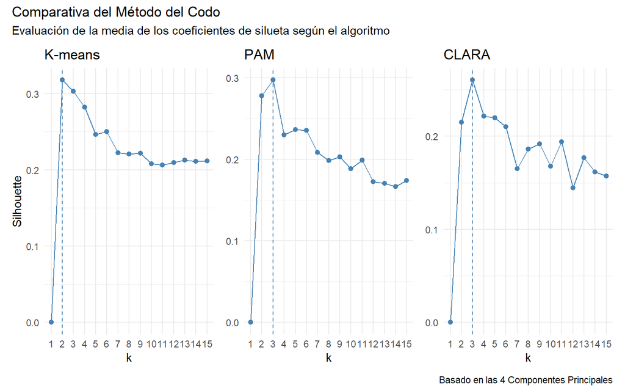

```r
p_km <- fviz_nbclust(x = datos_para_clustering, FUNcluster = kmeans, method = "silhouette",
                     k.max = 15, diss = get_dist(datos_para_clustering, method = "euclidean"), nstart = 50) +
        labs(title = "K-means", x = "k", y = "Silhouette") +
        theme_minimal()

p_pam <- fviz_nbclust(x = datos_para_clustering, FUNcluster = pam, method = "silhouette",
                      k.max = 15, diss = get_dist(datos_para_clustering, method = "euclidean")) +
         labs(title = "PAM", x = "k", y = NULL) +
         theme_minimal()

p_clara <- fviz_nbclust(x = datos_para_clustering, FUNcluster = clara, method = "silhouette",
                        k.max = 15, diss = get_dist(datos_para_clustering, method = "euclidean")) +
           labs(title = "CLARA", x = "k", y = NULL) +
           theme_minimal()

(p_km | p_pam | p_clara) +
  plot_annotation(title = "Comparativa del Método del Codo",
                  subtitle = "Evaluación de la media de los coeficientes de silueta según el algoritmo",
                  caption = "Basado en las 4 Componentes Principales")
```

Vemos que para todos los métodos, un bajo número de clústers ofrecen una mayor media de los coeficientes silueta. Sin embargo, si nos quedáramos con k = 2, nuestro objetivo de identificar arquetipos sería muy pobre y superficial. Es por eso que a la vista de las gráficas, elegir 6 clusters nos parece un buen equilibrio entre tener suficientes arquetipos de los que poder sacar conclusiones y un valor aceptable de los coeficientes de siluetas.

Ahora, creamos todos los clusters y realizamos un análisis Silhouette para ver cual de ellos ha funcionado mejor. Para ello, para cada cluster, sacamos el coeficiente de silueta de cada observación y realizamos la media de todos ellos por cluster.

```r
set.seed(123)
km_clusters <- kmeans(x = datos_para_clustering, centers = 6, nstart = 50)
pam_clusters <- pam(x = datos_para_clustering, k = 6, nstart = 50)
clara_clusters <- clara(x = datos_para_clustering, k = 6, samples = 50)


sil_km <- silhouette(km_clusters$cluster, dist(datos_para_clustering))
sil_pam <- silhouette(pam_clusters$clustering, dist(datos_para_clustering))
sil_clara <- silhouette(clara_clusters$clustering, dist(datos_para_clustering))
```

```r
resultados_sil <- data.frame(
  Algoritmo = c("K-means", "PAM", "CLARA"),
  `Ancho de Silueta Medio` = c(mean(sil_km[, 3]), mean(sil_pam[, 3]), mean(sil_clara[, 3])))

kable(resultados_sil, align = "c")
```

| Algoritmo | Ancho.de.Silueta.Medio |
| --- | --- |
| K-means | 0.2501812 |
| PAM | 0.2357707 |
| CLARA | 0.2102673 |

Observamos que el algoritmo k-means es el que nos ofrece un mejor rendimiento con un valor de 0.2501812, aunque los valores del resto de métodos son similares, por eso mismo elegimos el método K-means para realizar los clusters.

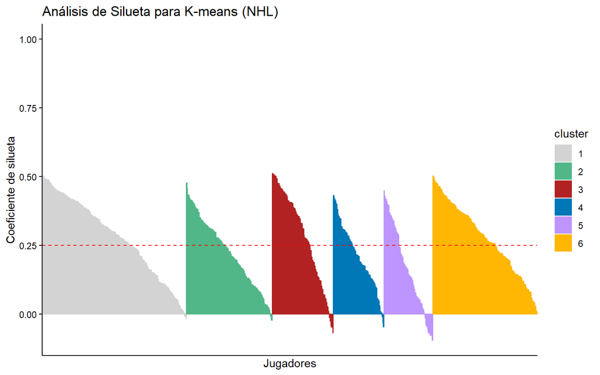

```r
colores_clusters <- c(
  "1" = "#D3D3D3",
  "2" = "#52B788",
  "3" = "#B22222",
  "4" = "#0077B6",
  "5" = "#BE95FF",
  "6" = "#FFB703")

fviz_silhouette(sil_km, print.summary = FALSE,
                ggtheme = theme_classic(),
                palette = colores_clusters) +
  labs(title = "Análisis de Silueta para K-means (NHL)", x = "Jugadores", y = "Coeficiente de silueta")
```

El gráfico de análisis de silueta para el modelo K-means muestra una estructura de seis clústeres con una cohesión interna razonable, donde la mayoría de los jugadores presentan coeficientes positivos, lo que indica que están correctamente asignados a sus respectivos arquetipos tácticos. La línea roja punteada representa la anchura media de la silueta (0.25), y se observa que los clústeres 3 (rojo), 4 (azul) y 6 (amarillo) tienen una proporción significativa de sus miembros por encima de este promedio, destacando como grupos especialmente bien definidos. Por el contrario, la presencia de pequeñas franjas negativas en la base de casi todos los grupos señala la existencia de jugadores en zonas de transición que comparten características de múltiples perfiles, aunque la escasez de estos valores negativos confirma que la partición de seis grupos es robusta y minimiza los errores de clasificación individual.

## CLUSTERS JERÁRQUICOS

Tras hacer un analisis con clusters de partición, vamos a compararlos con los jerárquicos, donde estableceremos de nuevo k=6

Analizaremos un método aglomerativo y otro divisorio, con los algoritmos AGNES y DIANA respectivamente, ambos empleando la distancia euclídea.

```r
# Usamos hcut para realizar el corte y obtener la silueta directamente
set.seed(123)
hc_corta_comp  <- hcut(x = datos_para_clustering, k = 6, hc_func = "hclust", hc_method = "complete")
hc_corta_avg   <- hcut(x = datos_para_clustering, k = 6, hc_func = "hclust", hc_method = "average")
hc_corta_ward  <- hcut(x = datos_para_clustering, k = 6, hc_func = "hclust", hc_method = "ward.D2")
hc_corta_diana <- hcut(x = datos_para_clustering, k = 6, hc_func = "diana")
```

```r
resultados_clustering <- data.frame(
  Metodo = c("AGNES Complete", "AGNES Average", "AGNES Ward", "DIANA"),
  Silueta_Promedio = c(
    hc_corta_comp$silinfo$avg.width,
    hc_corta_avg$silinfo$avg.width,
    hc_corta_ward$silinfo$avg.width,
    hc_corta_diana$silinfo$avg.width
  )
)
kable(resultados_clustering, align = "c")
```

| Metodo | Silueta_Promedio |
| --- | --- |
| AGNES Complete | 0.1378512 |
| AGNES Average | 0.2167308 |
| AGNES Ward | 0.2088670 |
| DIANA | 0.2561594 |

A la vista de los resultados, el algoritmo DIANA es el que ofrece un mejor rendimiento con un valor de 0.2561594, superando ligeramente al promedio obtenido por K-means (0.2501812).

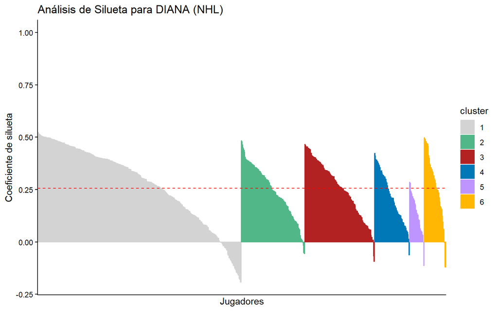

```r
colores_clusters <- c(
  "1" = "#D3D3D3",
  "2" = "#52B788",
  "3" = "#B22222",
  "4" = "#0077B6",
  "5" = "#BE95FF",
  "6" = "#FFB703")

# Análisis de silueta para el modelo DIANA
fviz_silhouette(hc_corta_diana,
                print.summary = FALSE,
                ggtheme = theme_classic(),
                palette = colores_clusters) +
  labs(title = "Análisis de Silueta para DIANA (NHL)",
       x = "Jugadores",
       y = "Coeficiente de silueta")
```

Aunque el coeficiente de silueta de DIANA es ligeramente superior por apenas 0,006, esta diferencia resulta estadísticamente marginal y no compensa las ventajas operativas y de estabilidad que ofrece K-means. Al observar detenidamente las gráficas de silueta, se aprecia que K-means minimiza de forma más eficiente las asignaciones erróneas, presentando menos observaciones con valores negativos y evitando el colapso de grupos pequeños, como ocurre con el Arquetipo 5 en el método divisorio. Además,su definición basada en centroides permite una escalabilidad y una facilidad de reclasificación de nuevos jugadores mucho mayor.

Por tanto, la consistencia en la cohesión de los grupos y la eficiencia técnica de K-means lo convierten en una opción más fiable y equilibrada para definir los arquetipos tácticos de la NHL.

## VISUALIZACIÓN Y ANÁLISIS DE CLUSTERS OBTENIDOS

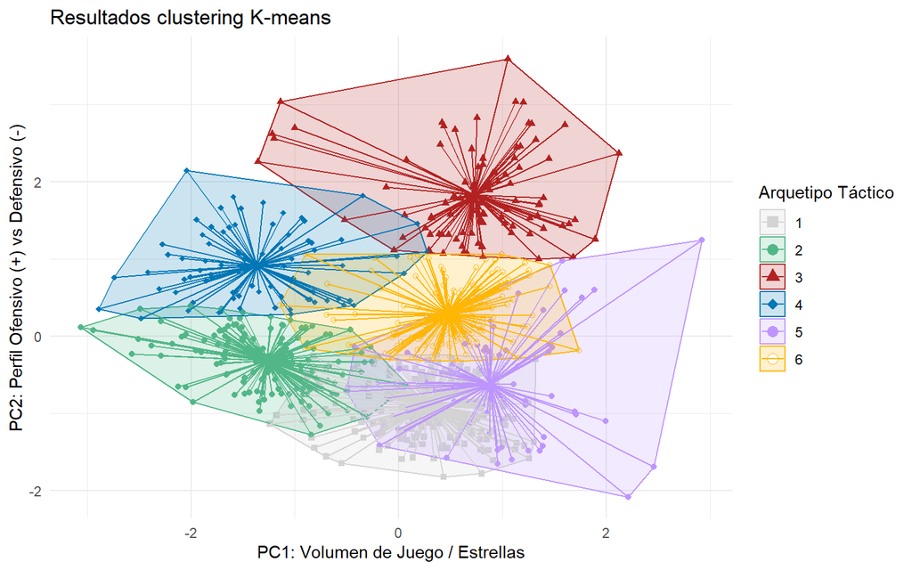

```r
# 1. Definimos los colores y formas para que sean consistentes
colores_clusters <- c(
  "1" = "#D3D3D3",
  "2" = "#52B788",
  "3" = "#B22222",
  "4" = "#0077B6",
  "5" = "#BE95FF",
  "6" = "#FFB703")

# 2. Creamos el gráfico unificado
fviz_cluster(object = km_clusters,
             data = datos_para_clustering,
             geom = "point",
             ellipse.type = "convex",
             show.clust.cent = TRUE,
             star.plot = TRUE) +

  scale_color_manual(name = "Arquetipo Táctico",
                     values = colores_clusters) +
  scale_fill_manual(name = "Arquetipo Táctico",
                    values = colores_clusters) +
  scale_shape_manual(name = "Arquetipo Táctico",
                     values = c(15, 16, 17, 18, 19, 21)) +

  labs(title = "Resultados clustering K-means",
       x = "PC1: Volumen de Juego / Estrellas",
       y = "PC2: Perfil Ofensivo (+) vs Defensivo (-)") +

  theme_minimal() +
  theme(legend.position = "right")
```

No podemos sacar demasiada información del gráfico ya que viéndolos solamente desde dos dimensiones, no se aprecia la verdadera separación entre los puntos. Por eso, para definir la identidad de cada arquetipo, calculamos los centroides de los seis clusters. La siguiente tabla muestra el valor promedio de las cuatro componentes principales en cada grupo, lo que nos permite bautizar a cada cluster según su comportamiento predominante.

```r
# Calculamos la media de las 4 PCs para cada cluster
centroides_km <- as.data.frame(km_clusters$centers)
centroides_km$cluster <- 1:6
centroides_km %>% kable()
```

| PC1 | PC2 | PC3 | PC4 | cluster |
| --- | --- | --- | --- | --- |
| -1.7723009 | 0.8571992 | 0.2839414 | 0.0815137 | 1 |
| -0.6237627 | -1.6941187 | 0.6263633 | -0.1841243 | 2 |
| 3.6195400 | 0.8968993 | -0.4541364 | 0.0230263 | 3 |
| 1.8063769 | -1.8554067 | 0.7868038 | 0.3246311 | 4 |
| -1.2374209 | -0.7670271 | -2.2011355 | -0.0989044 | 5 |
| 0.5511399 | 0.9436064 | 0.0027746 | -0.0857948 | 6 |

Para un análisis más claro, representaremos esta tabla de manera más visual mediante un heatmap:

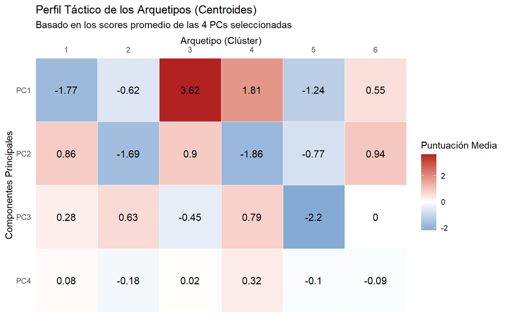

```r
centroides_km <- as.data.frame(km_clusters$centers)
centroides_km$cluster <- 1:6
centroides_km_melt <- melt(centroides_km, id.vars = "cluster")

ggplot(centroides_km_melt, aes(x = as.factor(cluster), y = fct_rev(variable), fill = value)) +
  geom_tile(color = "white") +
  scale_fill_gradient2(low = "#0077B6", high = "#B22222", mid = "white",
                       midpoint = 0, name = "Puntuación Media") +
  geom_text(aes(label = round(value, 2)), size = 4) +
  theme_minimal() +
  labs(title = "Perfil Táctico de los Arquetipos (Centroides)",
       x = "Arquetipo (Clúster)",
       y = "Componentes Principales",
       subtitle = "Basado en los scores promedio de las 4 PCs seleccionadas") +
  scale_x_discrete(position = "top", expand = c(0,0)) +
  scale_y_discrete(expand = c(0,0))
```

Tras analizar la distribución de los jugadores en el espacio de las Componentes Principales (PCs), se identifican 6 perfiles tácticos bien diferenciados que explican la estructura de la liga.

Por ejemplo, se diferencian jugadores con gran carga en la PC1 (clúster 3), esto son jugadores con alta participación ofensiva y volumen de juego. Son a priori, el grupo de jugadores franquicia. Por otro lado, se observa que el clúster 4 está claramente formado por jugadores de un perfil más sacrificado y defensivo, con alta carga negativa en la PC2. Además, los valores positivos de la PC1 y la PC3 indican que es el grupo de defensas de élite, con un alto volumen de juego y que debido a su alto nivel, no necesitan tanta agresividad si no que basan las defensa en su talento. A diferencia de ellos encontramos el cluster 5, que está compuesto claramente por jugadores con gran capacidad física y una alta agresividad (PC3 muy negativa).

También resulta interesante cómo el modelo separa dos tipos de juego defensivo. Mientras el clúster 4 parece representar a los defensas de élite que dominan por posicionamiento y volumen de minutos, el clúster 2 se queda en una zona de volumen bajo pero con una PC2 muy negativa. Esto indica que el algoritmo distingue perfectamente entre un defensor ‘top’ y un especialista que entra en situaciones específicas solo para bloquear tiros y defender el resultado.

Se observa además que el clúster 6 ocupa un lugar interesante: tienen una carga positiva en la PC2 pero un volumen (PC1) mucho más discreto que los jugadores estrella. Esto sugiere que son especialistas; jugadores que quizás no pasan tanto tiempo en el hielo, pero que cuando están, tienen un rol claramente orientado a buscar la portería rival. Por último, el bajo valor del clúster 1 en la PC1 nos lleva a pensar que son los jugadores de un nivel más bajo y con muy poca participación en el juego.

A continuación procedemos a la explicación de cada arquetipo trasladando el análisis de nuevo a las variables originales (goles, asistencias, bloqueos, etc.). Creemos que este paso es fundamental para dotar de interpretabilidad al estudio, permitiendo que entrenadores, analistas deportivos o gente no experta (quienes no necesariamente dominan el lenguaje estadístico del PCA) puedan validar, aplicar e interpretar los diferentes perfiles tácticos obtenidos en el contexto real del juego.

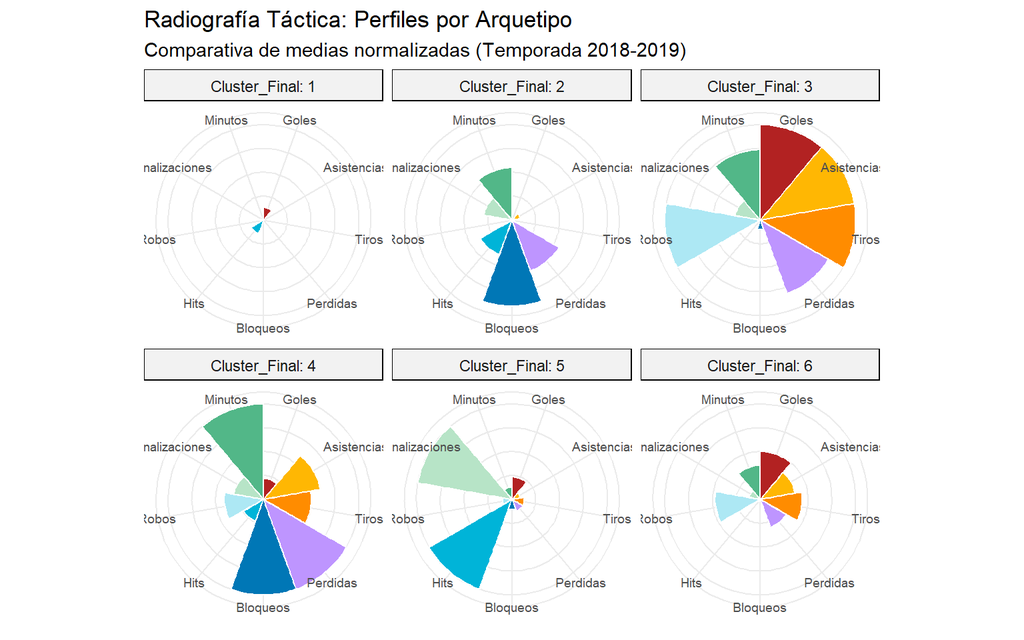

```r
data_con_clusters <- data_jugadores %>%
  mutate(Cluster_Final = as.factor(km_clusters$cluster))

orden_logico <- c("Goles", "Asistencias", "Tiros",
                  "Perdidas", "Bloqueos",
                  "Hits", "Robos", "Penalizaciones",
                  "Minutos")
# 1. Definición de la paleta Pro-Analytics (Tonos ajustados y claros)

mis_colores <- c(
  # ATAQUE
  "Goles"          = "#B22222",
  "Asistencias"    = "#FFB703",
  "Tiros"          = "#FF8C00",
  # DEFENSA
  "Bloqueos"       = "#0077B6",
  "Robos"          = "#ADE8F4",
  "Hits"           = "#00B4D8",
  "Perdidas"       = "#BE95FF",
  # TIEMPO Y DISCIPLINA
  "Minutos"        = "#52B788",
  "Penalizaciones" = "#B7E4C7"
)


# 2. Preparamos el resumen con este orden
resumen_radar_limpio <- data_con_clusters %>%
  group_by(Cluster_Final) %>%
  summarise(
    Goles = mean(goals, na.rm = TRUE),
    Asistencias = mean(assists, na.rm = TRUE),
    Tiros = mean(shots, na.rm = TRUE),
    Robos = mean(takeaways, na.rm = TRUE),
    Perdidas = mean(giveaways, na.rm = TRUE),
    Hits = mean(hits, na.rm = TRUE),
    Bloqueos = mean(blocked, na.rm = TRUE),
    Penalizaciones = mean(penaltyMinutes, na.rm = TRUE),
    Minutos = mean(timeOnIce, na.rm = TRUE)) %>%
  # Normalizamos 0-1
  mutate(across(-Cluster_Final, ~ scales::rescale(., to = c(0, 1)))) %>%
  pivot_longer(cols = -Cluster_Final, names_to = "Variable", values_to = "Valor") %>%
  mutate(Variable = factor(Variable, levels = orden_logico))

# 3. Gráfico de Rosas
ggplot(resumen_radar_limpio, aes(x = Variable, y = Valor, fill = Variable)) +
  geom_bar(stat = "identity", width = 1, color = "white") +
  coord_polar() +
  facet_wrap(~ Cluster_Final, labeller = label_both) +
  scale_fill_manual(values = mis_colores) +  theme_minimal() +
  labs(
    title = "Radiografía Táctica: Perfiles por Arquetipo",
    subtitle = "Comparativa de medias normalizadas (Temporada 2018-2019)",
    x = NULL, y = NULL
  ) +
  theme(
    axis.text.x = element_text(size = 7),
    axis.text.y = element_blank(),
    legend.position = "none",
    strip.background = element_rect(fill = "gray95")
  )
```

En el espacio de las variables originales, la interpretación resulta más sencilla lo cual nos permite darle un nombre más claro a nuestros arquetipos tácticos y definirlos de manera más precisa usando tanto la información obtenida en el espacio de las PCA como la interpretación de estadísticas mas sencillas como goles, asistencias, tiros bloqueados…

**1. Benchwarmers**

**2. Bloqueadores defensivos**

**3. Superestrellas Ofensivas**

**4. Muros de Élite**

**5. Especialistas Físicos**

**6. Jugadores de Rotación**

```r
data_jugadores_con_clusters <- cbind(data_con_clusters, pca2$x)
data_norm_global <- data_jugadores_con_clusters %>%
  mutate(across(c(goals, assists, shots, blocked, takeaways, hits, giveaways, timeOnIce, penaltyMinutes), ~ scales::rescale(.x)))
```

#### CLUSTER 1: Benchwarmers

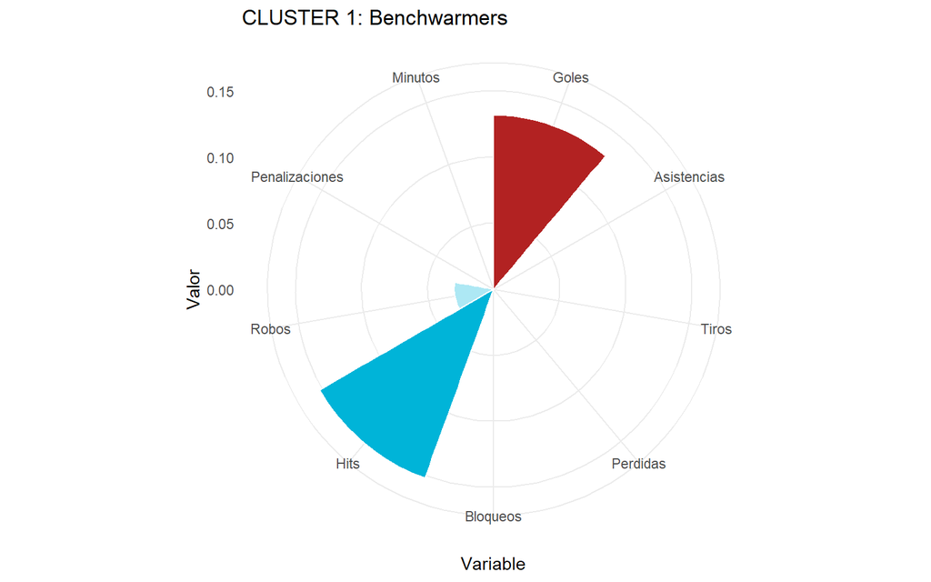

```r
cluster_a_ver <- "1"

ggplot(resumen_radar_limpio %>% filter(Cluster_Final == cluster_a_ver),
       aes(x = Variable, y = Valor, fill = Variable)) +
  geom_bar(stat = "identity", width = 1, color = "white") +
  coord_polar() +
  scale_fill_manual(values = mis_colores) +
  theme_minimal() +
  labs(title = paste("CLUSTER 1: Benchwarmers")) +
  theme(legend.position = "none")
```

Este grupo se caracteriza por tener el valor más bajo de volumen de juego. Son jugadores con una participación muy limitada en el hielo y estadísticas discretas en todas las áreas. Aunque muestran una ligera tendencia ofensiva, su impacto real en el juego es mínimo debido a la falta de minutos.

A continuación mostramos 5 jugadores que son ejemplos representativos de este arquetipo.

```r
data_cluster1 <- data_jugadores_con_clusters %>% filter(Cluster_Final == "1")
centroide_c1 <- km_clusters$centers[1, ]


pcs_nombres <- colnames(km_clusters$centers)



# Calcular la distancia euclidiana en el espacio de las PCs
data_cluster1$distancia_centroide <- apply(data_cluster1[, pcs_nombres], 1, function(fila) {sqrt(sum((fila - centroide_c1)^2))})

# Ordenar: los más cercanos al centro son los "Prototipos"
jugadores_representativos_1 <- data_cluster1 %>%
  arrange(distancia_centroide) %>%
  select(firstName, lastName, nationality, primaryPosition, goals, assists, shots, hits, blocked, takeaways, giveaways, penaltyMinutes, timeOnIce, plusMinus, faceOffRatio, partidos_jugados) %>%
  head(5)

jugadores_representativos_1 %>% kable()
```

| firstName | lastName | nationality | primaryPosition | goals | assists | shots | hits | blocked | takeaways | giveaways | penaltyMinutes | timeOnIce | plusMinus | faceOffRatio | partidos_jugados |
| --- | --- | --- | --- | --- | --- | --- | --- | --- | --- | --- | --- | --- | --- | --- | --- |
| Eric | Fehr | CAN | C | 0.0972222 | 0.1111111 | 0.9305556 | 0.5555556 | 0.6666667 | 0.4444444 | 0.1666667 | 0.4166667 | 662.5694 | -0.1111111 | 0.5133992 | 72 |
| Colby | Cave | CAN | C | 0.0566038 | 0.0943396 | 1.0943396 | 1.3773585 | 0.3396226 | 0.4150943 | 0.2264151 | 0.3018868 | 738.7736 | -0.0943396 | 0.5012531 | 53 |
| Drew | Stafford | USA | RW | 0.0877193 | 0.1403509 | 1.3508772 | 0.8771930 | 0.3333333 | 0.2631579 | 0.2982456 | 0.3157895 | 735.9298 | -0.1228070 | 0.4102564 | 57 |
| Derek | Grant | CAN | C | 0.0714286 | 0.1785714 | 1.3214286 | 1.6428571 | 0.5178571 | 0.3392857 | 0.2500000 | 0.2500000 | 701.1964 | -0.1071429 | 0.5262136 | 56 |
| Riley | Nash | CAN | C | 0.0470588 | 0.1294118 | 1.0352941 | 1.0470588 | 0.5529412 | 0.5294118 | 0.1647059 | 0.2705882 | 663.7294 | -0.0705882 | 0.4507463 | 85 |

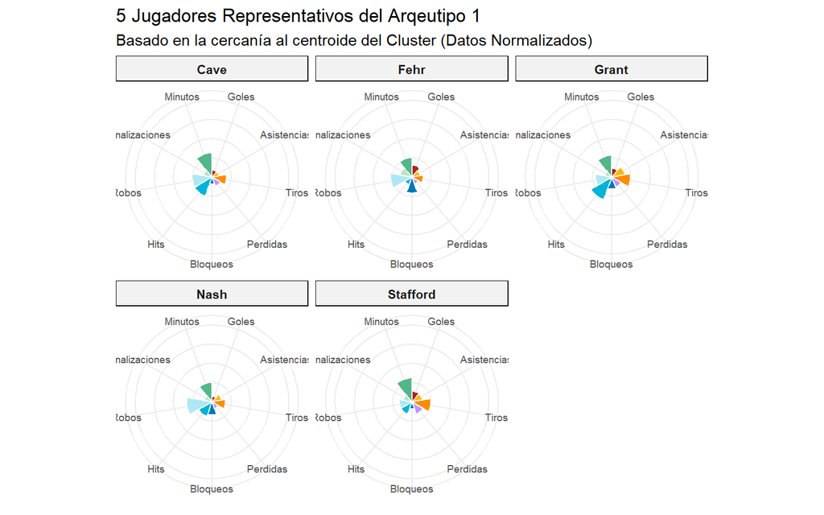

```r
# Seleccionamos solo las variables de juego + el nombre
top5_1 <- data_norm_global %>%
  filter(Cluster_Final == "1")


top5_1$distancia_centroide <- apply(data_cluster1[, pcs_nombres], 1, function(fila) {sqrt(sum((fila - centroide_c1)^2))})

jugadores_representativos_long <-  top5_1 %>%
  arrange(distancia_centroide) %>%
  head(5)  %>%
  select(lastName, goals, assists, shots, blocked, takeaways, hits, giveaways, timeOnIce, penaltyMinutes) %>%
  rename(Goles = goals, Asistencias = assists, Tiros = shots,
         Bloqueos = blocked, Robos = takeaways, Hits = hits,
         Perdidas = giveaways, Minutos = timeOnIce, Penalizaciones = penaltyMinutes) %>%
  pivot_longer(-lastName, names_to = "Variable", values_to = "Valor") %>%
  mutate(Variable = factor(Variable, levels = orden_logico))


ggplot(jugadores_representativos_long, aes(x = Variable, y = Valor, fill = Variable)) +
  geom_bar(stat = "identity", width = 1, color = "white") +
  coord_polar() +
  facet_wrap(~ lastName) + # Esto crea los 5 mini-gráficos
  scale_fill_manual(values = mis_colores) +
  scale_y_continuous(limits = c(0, 1)) +
  theme_minimal() +
  labs(
    title = "5 Jugadores Representativos del Arqeutipo 1",
    subtitle = "Basado en la cercanía al centroide del Cluster (Datos Normalizados)",
    x = NULL, y = NULL) +
  theme(
    axis.text.x = element_text(size = 7, angle = 0),
    axis.text.y = element_blank(),
    strip.background = element_rect(fill = "gray95"),
    strip.text = element_text(face = "bold"),
    legend.position = "none"
  )
```

Vemos que los gráficos de rosas de estos 5 jugadores son muy similares mostrando un volumen de minutos reducido y una producción ofensiva discreta.

Nombres como **Eric Fehr** o **Colby Cave** validan externamente el modelo, ya que sus carreras se han definido por la fiabilidad en roles de apoyo y veteranía en líneas de contención.

#### CLUSTER 2: Bloqueadores defensivos

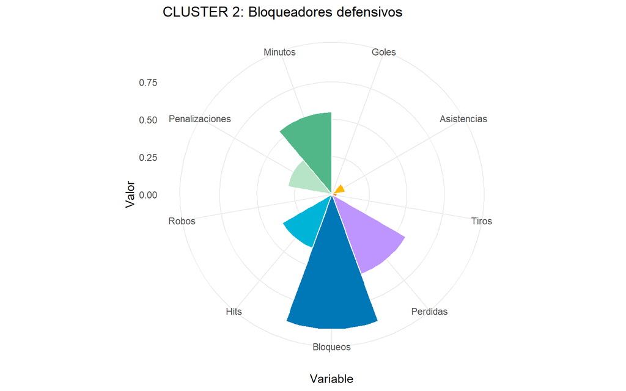

```r
cluster_a_ver <- "2"

ggplot(resumen_radar_limpio %>% filter(Cluster_Final == cluster_a_ver),
       aes(x = Variable, y = Valor, fill = Variable)) +
  geom_bar(stat = "identity", width = 1, color = "white") +
  coord_polar() +
  scale_fill_manual(values = mis_colores) +
  theme_minimal() +
  labs(title = paste("CLUSTER 2: Bloqueadores defensivos")) +
  theme(legend.position = "none")
```

Con un perfil puramente defensivo y una carga de minutos limitada, este arquetipo define a los defensores de rotación. Son perfiles conservadores que el entrenador despliega en situaciones de riesgo, como las inferioridades numéricas, priorizando el bloqueo de tiros y la seguridad por encima de cualquier aportación creativa.

```r
# 1. Definimos el ID del cluster que queremos analizar
cluster_id <- 2

# 2. Filtramos el cluster y extraemos SU centroide específico
data_cluster2 <- data_jugadores_con_clusters %>% filter(Cluster_Final == cluster_id)
centroide_c2 <- km_clusters$centers[cluster_id, ]

# 3. Calculamos la distancia
data_cluster2$distancia_centroide <- apply(data_cluster2[, pcs_nombres], 1, function(fila) {
  sqrt(sum((fila - centroide_c2)^2))
})

# 4. Seleccionamos los 5 prototipos del Cluster 2
jugadores_representativos_2 <- data_cluster2 %>%
  arrange(distancia_centroide) %>%
  select(firstName, lastName, nationality, primaryPosition, goals, assists,
         shots, hits, blocked, takeaways, giveaways, penaltyMinutes,
         timeOnIce, plusMinus, faceOffRatio, partidos_jugados) %>%
  head(5)

# 5. Visualizamos
jugadores_representativos_2 %>% kable()
```

| firstName | lastName | nationality | primaryPosition | goals | assists | shots | hits | blocked | takeaways | giveaways | penaltyMinutes | timeOnIce | plusMinus | faceOffRatio | partidos_jugados |
| --- | --- | --- | --- | --- | --- | --- | --- | --- | --- | --- | --- | --- | --- | --- | --- |
| Fredrik | Claesson | SWE | D | 0.0540541 | 0.1081081 | 1.1891892 | 2.0540541 | 0.8918919 | 0.2432432 | 0.8378378 | 0.2432432 | 1034.8919 | 0.0810811 | 0 | 37 |
| Derrick | Pouliot | CAN | D | 0.0483871 | 0.1451613 | 0.9354839 | 1.2258065 | 1.1451613 | 0.3064516 | 0.6290323 | 0.4838710 | 1029.5000 | -0.0161290 | 0 | 62 |
| Jake | McCabe | USA | D | 0.0677966 | 0.1694915 | 1.0847458 | 1.7457627 | 1.6779661 | 0.3389831 | 0.5423729 | 0.5932203 | 1136.6949 | -0.0677966 | 0 | 59 |
| Juuso | Valimaki | FIN | D | 0.0384615 | 0.1153846 | 1.1923077 | 0.9230769 | 1.6538462 | 0.3846154 | 0.6153846 | 0.4615385 | 934.9615 | -0.0384615 | 0 | 26 |
| Matt | Roy | USA | D | 0.0800000 | 0.1600000 | 1.3600000 | 1.5200000 | 1.8800000 | 0.1600000 | 0.6800000 | 0.3200000 | 1027.8400 | -0.0400000 | 0 | 25 |

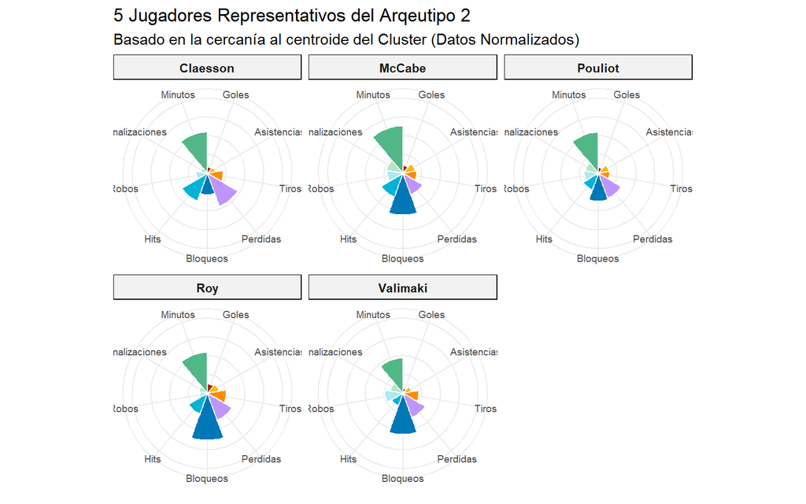

```r
# Seleccionamos solo las variables de juego + el nombre
top5_2 <- data_norm_global %>%
  filter(Cluster_Final == "2")


top5_2$distancia_centroide <- apply(data_cluster2[, pcs_nombres], 1, function(fila) {sqrt(sum((fila - centroide_c2)^2))})

jugadores_representativos_long <-  top5_2 %>%
  arrange(distancia_centroide) %>%
  head(5)  %>%
  select(lastName, goals, assists, shots, blocked, takeaways, hits, giveaways, timeOnIce, penaltyMinutes) %>%
  rename(Goles = goals, Asistencias = assists, Tiros = shots,
          Robos = takeaways, Perdidas = giveaways, Hits = hits, Bloqueos = blocked,  Penalizaciones = penaltyMinutes, Minutos = timeOnIce) %>%
  pivot_longer(-lastName, names_to = "Variable", values_to = "Valor") %>%
  mutate(Variable = factor(Variable, levels = orden_logico))

ggplot(jugadores_representativos_long, aes(x = Variable, y = Valor, fill = Variable)) +
  geom_bar(stat = "identity", width = 1, color = "white") +
  coord_polar() +
  facet_wrap(~ lastName) + # Esto crea los 5 mini-gráficos
  scale_fill_manual(values = mis_colores) +
  scale_y_continuous(limits = c(0, 1)) +
  theme_minimal() +
  labs(
    title = "5 Jugadores Representativos del Arqeutipo 2",
    subtitle = "Basado en la cercanía al centroide del Cluster (Datos Normalizados)",
    x = NULL, y = NULL) +
  theme(
    axis.text.x = element_text(size = 7, angle = 0),
    axis.text.y = element_blank(),
    strip.background = element_rect(fill = "gray95"),
    strip.text = element_text(face = "bold"),
    legend.position = "none"
  )
```

Jugadores como **Claesson** o **McCabe** encajan perfectamente aquí, ya que son conocidos en la liga por ser defensores de corte defensivo puro, lo que valida empíricamente estos resultados.

#### CLUSTER 3: Superestrellas ofensivas

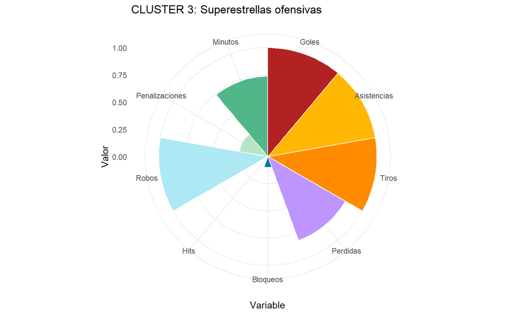

```r
cluster_a_ver <- "3"

ggplot(resumen_radar_limpio %>% filter(Cluster_Final == cluster_a_ver),
       aes(x = Variable, y = Valor, fill = Variable)) +
  geom_bar(stat = "identity", width = 1, color = "white") +
  coord_polar() +
  scale_fill_manual(values = mis_colores) +
  theme_minimal() +
  labs(title = paste("CLUSTER 3: Superestrellas ofensivas")) +
  theme(legend.position = "none")
```

```r
# 1. Definimos el ID del cluster que queremos analizar
cluster_id <- 3

# 2. Filtramos el cluster y extraemos SU centroide específico
data_cluster3 <- data_jugadores_con_clusters %>% filter(Cluster_Final == cluster_id)
centroide_c3 <- km_clusters$centers[cluster_id, ]

# 3. Calculamos la distancia
data_cluster3$distancia_centroide <- apply(data_cluster3[, pcs_nombres], 1, function(fila) {
  sqrt(sum((fila - centroide_c3)^2))
})

# 4. Seleccionamos los 5 prototipos del Cluster 2
jugadores_representativos_3 <- data_cluster3 %>%
  arrange(distancia_centroide) %>%
  select(firstName, lastName, nationality, primaryPosition, goals, assists,
         shots, hits, blocked, takeaways, giveaways, penaltyMinutes,
         timeOnIce, plusMinus, faceOffRatio, partidos_jugados) %>%
  head(5)

# 5. Visualizamos
jugadores_representativos_3 %>% kable()
```

| firstName | lastName | nationality | primaryPosition | goals | assists | shots | hits | blocked | takeaways | giveaways | penaltyMinutes | timeOnIce | plusMinus | faceOffRatio | partidos_jugados |
| --- | --- | --- | --- | --- | --- | --- | --- | --- | --- | --- | --- | --- | --- | --- | --- |
| Mark | Scheifele | CAN | C | 0.4494382 | 0.5505618 | 2.438202 | 0.6179775 | 0.6741573 | 0.8764045 | 0.5730337 | 0.5168539 | 1297.506 | 0.0337079 | 0.4600107 | 89 |
| Evgeny | Kuznetsov | RUS | C | 0.2650602 | 0.6746988 | 2.542169 | 0.5783133 | 0.2771084 | 0.5903614 | 0.7831325 | 0.6265060 | 1133.337 | 0.0722892 | 0.3895760 | 83 |
| Sean | Couturier | CAN | C | 0.4125000 | 0.5375000 | 2.787500 | 0.5000000 | 0.7500000 | 0.5875000 | 0.6000000 | 0.4250000 | 1327.625 | 0.0250000 | 0.5706727 | 80 |
| Logan | Couture | CAN | C | 0.4059406 | 0.4851485 | 2.683168 | 1.0297030 | 0.7227723 | 0.9108911 | 0.4356436 | 0.2772277 | 1134.079 | -0.0297030 | 0.4640754 | 101 |
| Jonathan | Toews | CAN | C | 0.4268293 | 0.5609756 | 2.865854 | 0.5121951 | 0.5365854 | 0.8780488 | 0.6341463 | 0.4878049 | 1260.415 | 0.0243902 | 0.5632979 | 82 |

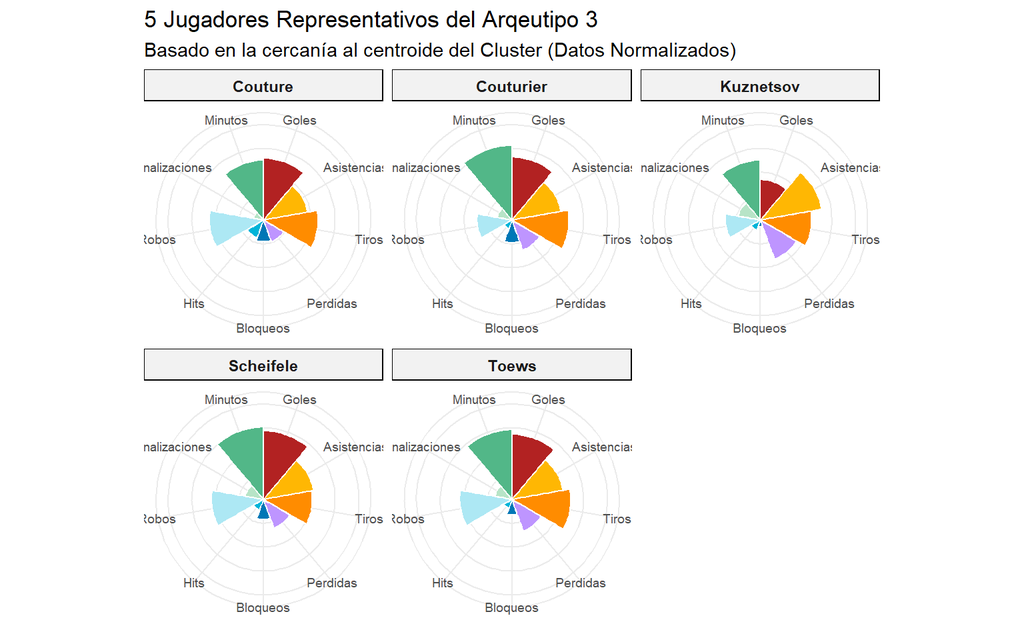

```r
# Seleccionamos solo las variables de juego + el nombre
top5_3 <- data_norm_global %>%
  filter(Cluster_Final == "3")


top5_3$distancia_centroide <- apply(data_cluster3[, pcs_nombres], 1, function(fila) {sqrt(sum((fila - centroide_c3)^2))})

jugadores_representativos_long <-  top5_3 %>%
  arrange(distancia_centroide) %>%
  head(5)  %>%
  select(lastName, goals, assists, shots, blocked, takeaways, hits, giveaways, timeOnIce, penaltyMinutes) %>%
  rename(Goles = goals, Asistencias = assists, Tiros = shots,
          Robos = takeaways, Perdidas = giveaways, Hits = hits, Bloqueos = blocked,  Penalizaciones = penaltyMinutes, Minutos = timeOnIce) %>%
  pivot_longer(-lastName, names_to = "Variable", values_to = "Valor") %>%
  mutate(Variable = factor(Variable, levels = orden_logico))

ggplot(jugadores_representativos_long, aes(x = Variable, y = Valor, fill = Variable)) +
  geom_bar(stat = "identity", width = 1, color = "white") +
  coord_polar() +
  facet_wrap(~ lastName) + # Esto crea los 5 mini-gráficos
  scale_fill_manual(values = mis_colores) +
  scale_y_continuous(limits = c(0, 1)) +
  theme_minimal() +
  labs(
    title = "5 Jugadores Representativos del Arqeutipo 3",
    subtitle = "Basado en la cercanía al centroide del Cluster (Datos Normalizados)",
    x = NULL, y = NULL) +
  theme(
    axis.text.x = element_text(size = 7, angle = 0),
    axis.text.y = element_blank(),
    strip.background = element_rect(fill = "gray95"),
    strip.text = element_text(face = "bold"),
    legend.position = "none"
  )
```

Esta visualización confirma la identidad de la élite ofensiva: jugadores que no solo destacan en una faceta, sino que dominan el volumen de juego completo. Nombres como **Couturier**, **Scheifele** o **Toews** validan el modelo, ya que representan a jugadores de primera línea con una capacidad única para generar peligro constante, asumiendo la mayor responsabilidad táctica de sus respectivos equipos.

#### CLUSTER 4: Muros de élite

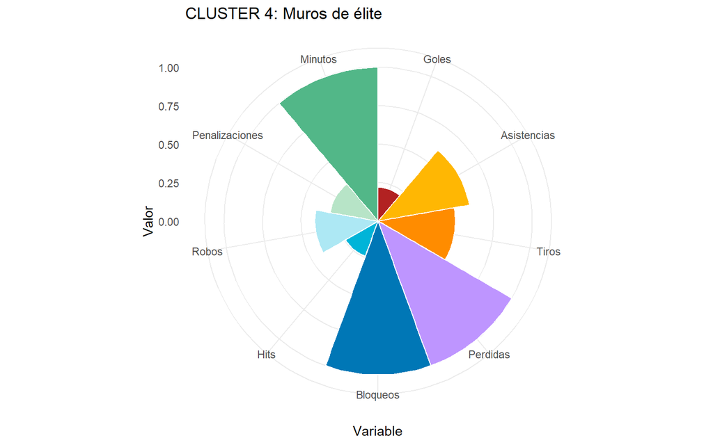

```r
cluster_a_ver <- "4"

ggplot(resumen_radar_limpio %>% filter(Cluster_Final == cluster_a_ver),
       aes(x = Variable, y = Valor, fill = Variable)) +
  geom_bar(stat = "identity", width = 1, color = "white") +
  coord_polar() +
  scale_fill_manual(values = mis_colores) +
  theme_minimal() +
  labs(title = paste("CLUSTER 4: Muros de élite")) +
  theme(legend.position = "none")
```

```r
# 1. Definimos el ID del cluster que queremos analizar
cluster_id <- 4

# 2. Filtramos el cluster y extraemos SU centroide específico
data_cluster4 <- data_jugadores_con_clusters %>% filter(Cluster_Final == cluster_id)
centroide_c4 <- km_clusters$centers[cluster_id, ]

# 3. Calculamos la distancia
data_cluster4$distancia_centroide <- apply(data_cluster4[, pcs_nombres], 1, function(fila) {
  sqrt(sum((fila - centroide_c4)^2))
})

# 4. Seleccionamos los 5 prototipos del Cluster 2
jugadores_representativos_4 <- data_cluster4 %>%
  arrange(distancia_centroide) %>%
  select(firstName, lastName, nationality, primaryPosition, goals, assists,
         shots, hits, blocked, takeaways, giveaways, penaltyMinutes,
         timeOnIce, plusMinus, faceOffRatio, partidos_jugados) %>%
  head(5)

# 5. Visualizamos
jugadores_representativos_4 %>% kable()
```

| firstName | lastName | nationality | primaryPosition | goals | assists | shots | hits | blocked | takeaways | giveaways | penaltyMinutes | timeOnIce | plusMinus | faceOffRatio | partidos_jugados |
| --- | --- | --- | --- | --- | --- | --- | --- | --- | --- | --- | --- | --- | --- | --- | --- |
| Dmitry | Orlov | RUS | D | 0.0337079 | 0.3370787 | 1.247191 | 1.7078652 | 1.202247 | 0.6404494 | 0.9775281 | 0.4157303 | 1306.427 | 0.0112360 | 0 | 89 |
| Mike | Green | CAN | D | 0.1162791 | 0.4883721 | 2.139535 | 1.3953488 | 1.302326 | 0.3720930 | 1.1395349 | 0.6511628 | 1300.651 | -0.0232558 | 0 | 43 |
| Ryan | Suter | USA | D | 0.0853659 | 0.4878049 | 1.658537 | 0.9512195 | 1.329268 | 0.3048780 | 0.3658537 | 0.5000000 | 1601.524 | -0.0975610 | 1 | 82 |
| P.K. | Subban | CAN | D | 0.1449275 | 0.3478261 | 2.695652 | 0.9275362 | 1.304348 | 0.3333333 | 0.8985507 | 0.8695652 | 1374.565 | 0.0289855 | 0 | 69 |
| Erik | Gustafsson | SWE | D | 0.2151899 | 0.5443038 | 2.025317 | 1.2658228 | 1.455696 | 0.4303797 | 0.9746835 | 0.4303797 | 1355.076 | -0.0759494 | 0 | 79 |

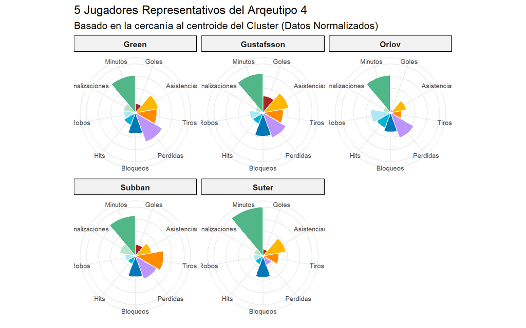

```r
# Seleccionamos solo las variables de juego + el nombre
top5_4 <- data_norm_global %>%
  filter(Cluster_Final == "4")


top5_4$distancia_centroide <- apply(data_cluster4[, pcs_nombres], 1, function(fila) {sqrt(sum((fila - centroide_c4)^2))})

jugadores_representativos_long <-  top5_4 %>%
  arrange(distancia_centroide) %>%
  head(5)  %>%
  select(lastName, goals, assists, shots, blocked, takeaways, hits, giveaways, timeOnIce, penaltyMinutes) %>%
  rename(Goles = goals, Asistencias = assists, Tiros = shots,
          Robos = takeaways, Perdidas = giveaways, Hits = hits, Bloqueos = blocked,  Penalizaciones = penaltyMinutes, Minutos = timeOnIce) %>%
  pivot_longer(-lastName, names_to = "Variable", values_to = "Valor") %>%
  mutate(Variable = factor(Variable, levels = orden_logico))

ggplot(jugadores_representativos_long, aes(x = Variable, y = Valor, fill = Variable)) +
  geom_bar(stat = "identity", width = 1, color = "white") +
  coord_polar() +
  facet_wrap(~ lastName) + # Esto crea los 5 mini-gráficos
  scale_fill_manual(values = mis_colores) +
  scale_y_continuous(limits = c(0, 1)) +
  theme_minimal() +
  labs(
    title = "5 Jugadores Representativos del Arqeutipo 4",
    subtitle = "Basado en la cercanía al centroide del Cluster (Datos Normalizados)",
    x = NULL, y = NULL) +
  theme(
    axis.text.x = element_text(size = 7, angle = 0),
    axis.text.y = element_blank(),
    strip.background = element_rect(fill = "gray95"),
    strip.text = element_text(face = "bold"),
    legend.position = "none"
  )
```

Esta morfología táctica describe a defensores de alto impacto que no solo frenan a las estrellas rivales, sino que tienen la calidad necesaria para iniciar la salida del disco. Nombres como **Ryan Suter**, **P.K. Subban** o **Dmitry Orlov** son ejemplos claros de este rol: jugadores todoterreno que lideran el tiempo en hielo y cuya influencia es fundamental tanto en la solidez física como en la transición del juego.

#### **CLUSTER 5: Especialistas Físicos**

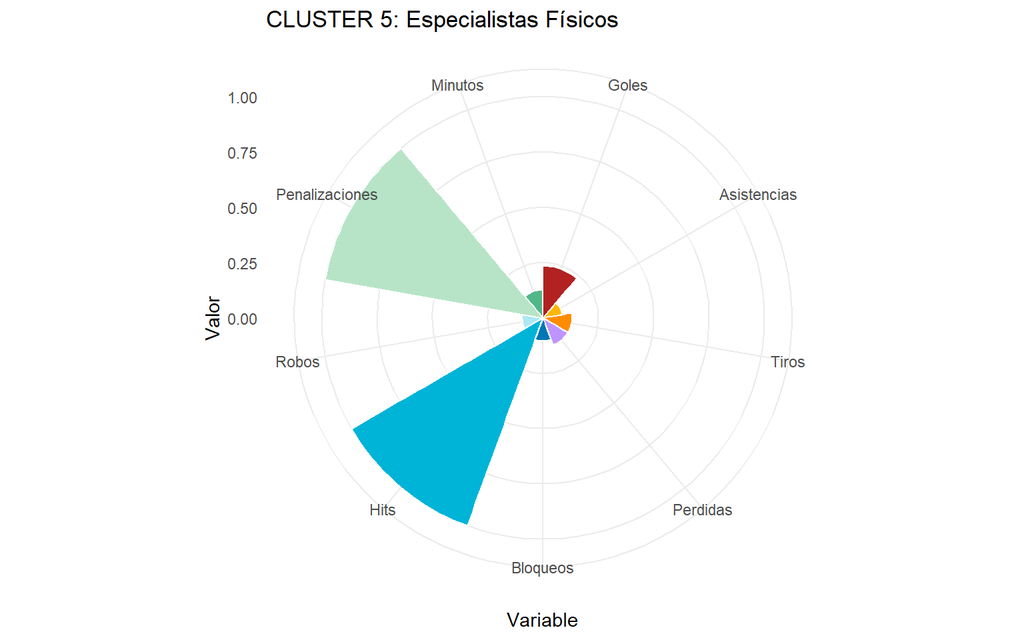

```r
cluster_a_ver <- "5"

ggplot(resumen_radar_limpio %>% filter(Cluster_Final == cluster_a_ver),
       aes(x = Variable, y = Valor, fill = Variable)) +
  geom_bar(stat = "identity", width = 1, color = "white") +
  coord_polar() +
  scale_fill_manual(values = mis_colores) +
  theme_minimal() +
  labs(title = paste("CLUSTER 5: Especialistas Físicos")) +
  theme(legend.position = "none")
```

Un perfil muy específico definido por la tercera componente. Son jugadores que basan su juego en el contacto, la fricción y la protección del equipo. Al igual que los jugadores de rotación, suelen tener poco tiempo de juego, lo que confirma que su entrada en la pista responde a situaciones tácticas muy concretas de carácter físico.

```r
# 1. Definimos el ID del cluster que queremos analizar
cluster_id <- 5

# 2. Filtramos el cluster y extraemos SU centroide específico
data_cluster5 <- data_jugadores_con_clusters %>% filter(Cluster_Final == cluster_id)
centroide_c5 <- km_clusters$centers[cluster_id, ]

# 3. Calculamos la distancia
data_cluster5$distancia_centroide <- apply(data_cluster5[, pcs_nombres], 1, function(fila) {
  sqrt(sum((fila - centroide_c5)^2))
})

# 4. Seleccionamos los 5 prototipos del Cluster 2
jugadores_representativos_5 <- data_cluster5 %>%
  arrange(distancia_centroide) %>%
  select(firstName, lastName, nationality, primaryPosition, goals, assists,
         shots, hits, blocked, takeaways, giveaways, penaltyMinutes,
         timeOnIce, plusMinus, faceOffRatio, partidos_jugados) %>%
  head(5)

# 5. Visualizamos
jugadores_representativos_5 %>% kable()
```

| firstName | lastName | nationality | primaryPosition | goals | assists | shots | hits | blocked | takeaways | giveaways | penaltyMinutes | timeOnIce | plusMinus | faceOffRatio | partidos_jugados |
| --- | --- | --- | --- | --- | --- | --- | --- | --- | --- | --- | --- | --- | --- | --- | --- |
| Chris | Wagner | USA | RW | 0.1590909 | 0.0795455 | 1.750000 | 3.306818 | 0.5000000 | 0.2613636 | 0.2386364 | 0.6022727 | 799.8750 | 0.0000000 | 0.4444444 | 88 |
| Cal | Clutterbuck | CAN | RW | 0.1000000 | 0.1875000 | 1.300000 | 3.025000 | 0.5500000 | 0.2500000 | 0.4000000 | 0.6000000 | 843.6750 | 0.0250000 | 0.4411765 | 80 |
| Lawson | Crouse | CAN | LW | 0.1358025 | 0.1728395 | 1.617284 | 3.555556 | 0.5432099 | 0.3086420 | 0.2839506 | 0.8271605 | 776.8519 | 0.0617284 | 0.4137931 | 81 |
| Noel | Acciari | USA | C | 0.0879121 | 0.1098901 | 1.307692 | 3.241758 | 0.6373626 | 0.4175824 | 0.1758242 | 0.5164835 | 781.4176 | -0.0109890 | 0.4961089 | 91 |
| Blake | Comeau | CAN | LW | 0.0888889 | 0.1333333 | 1.266667 | 2.733333 | 0.5555556 | 0.4888889 | 0.4555556 | 0.6444444 | 949.2222 | -0.0777778 | 0.4354839 | 90 |

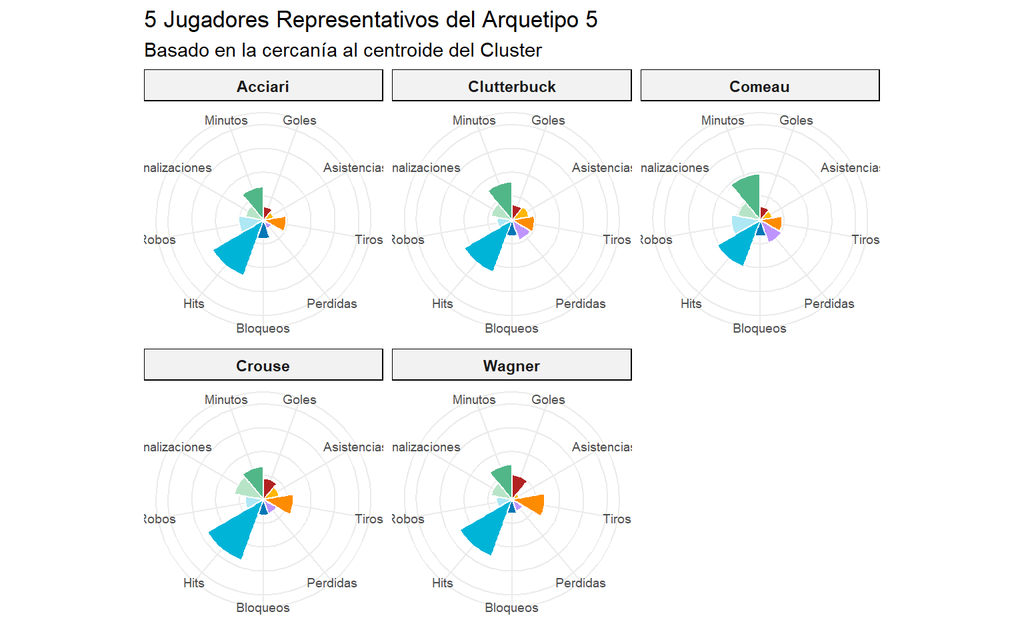

```r
# Seleccionamos solo las variables de juego + el nombre
top5_5 <- data_norm_global %>%
  filter(Cluster_Final == "5")


top5_5$distancia_centroide <- apply(data_cluster5[, pcs_nombres], 1, function(fila) {sqrt(sum((fila - centroide_c5)^2))})

jugadores_representativos_long <-  top5_5 %>%
  arrange(distancia_centroide) %>%
  head(5)  %>%
  select(lastName, goals, assists, shots, blocked, takeaways, hits, giveaways, timeOnIce, penaltyMinutes) %>%
  rename(Goles = goals, Asistencias = assists, Tiros = shots,
          Robos = takeaways, Perdidas = giveaways, Hits = hits, Bloqueos = blocked,  Penalizaciones = penaltyMinutes, Minutos = timeOnIce) %>%
  pivot_longer(-lastName, names_to = "Variable", values_to = "Valor") %>%
  mutate(Variable = factor(Variable, levels = orden_logico))

ggplot(jugadores_representativos_long, aes(x = Variable, y = Valor, fill = Variable)) +
  geom_bar(stat = "identity", width = 1, color = "white") +
  coord_polar() +
  facet_wrap(~ lastName) + # Esto crea los 5 mini-gráficos
  scale_fill_manual(values = mis_colores) +
  scale_y_continuous(limits = c(0, 1)) +
  theme_minimal() +
  labs(
    title = "5 Jugadores Representativos del Arquetipo 5",
    subtitle = "Basado en la cercanía al centroide del Cluster",
    x = NULL, y = NULL) +
  theme(
    axis.text.x = element_text(size = 7, angle = 0),
    axis.text.y = element_blank(),
    strip.background = element_rect(fill = "gray95"),
    strip.text = element_text(face = "bold"),
    legend.position = "none"
  )
```

Los gráficos de estos jugadores revelan una especialización táctica agresiva y sumamente consistente entre sus representantes. El gráfico de cada jugador muestra un pico desproporcionado y dominante en la métrica de Hits (cargas legales), que eclipsa casi por completo al resto de variables estadísticas.

Este patrón visual ratifica que estamos ante un perfil muy físico. A diferencia de los atacantes de volumen, su valor no reside en la acumulación de puntos, sino en la capacidad de alterar el ritmo del partido mediante el contacto físico y la intimidación. Nombres como **Cal Clutterbuck** o **Noel Acciari** personifican este rol a la perfección: jugadores que, en turnos limitados de juego, maximizan el impacto físico para desgastar al rival y proteger la integridad del equipo.

#### CLUSTER 6: Jugadores de rotación

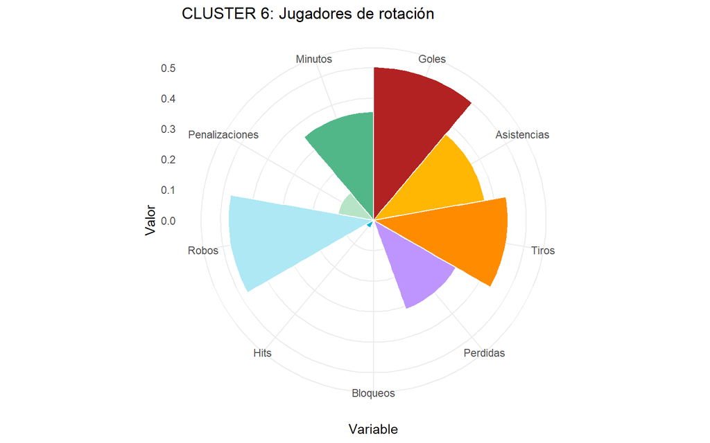

```r
cluster_a_ver <- "6"

ggplot(resumen_radar_limpio %>% filter(Cluster_Final == cluster_a_ver),
       aes(x = Variable, y = Valor, fill = Variable)) +
  geom_bar(stat = "identity", width = 1, color = "white") +
  coord_polar() +
  scale_fill_manual(values = mis_colores) +
  theme_minimal() +
  labs(title = paste("CLUSTER 6: Jugadores de rotación")) +
  theme(legend.position = "none")
```

Representan el equilibrio en el ataque. Con valores positivos moderados tanto en volumen como en ofensiva, se identifican como delanteros complementarios. Son piezas fundamentales que aportan consistencia y profundidad a sus plantillas.

```r
# 1. Definimos el ID del cluster que queremos analizar
cluster_id <- 6

# 2. Filtramos el cluster y extraemos SU centroide específico
data_cluster6 <- data_jugadores_con_clusters %>% filter(Cluster_Final == cluster_id)
centroide_c6 <- km_clusters$centers[cluster_id, ]

# 3. Calculamos la distancia
data_cluster6$distancia_centroide <- apply(data_cluster6[, pcs_nombres], 1, function(fila) {
  sqrt(sum((fila - centroide_c6)^2))
})

# 4. Seleccionamos los 5 prototipos del Cluster 2
jugadores_representativos_6 <- data_cluster6 %>%
  arrange(distancia_centroide) %>%
  select(firstName, lastName, nationality, primaryPosition, goals, assists,
         shots, hits, blocked, takeaways, giveaways, penaltyMinutes,
         timeOnIce, plusMinus, faceOffRatio, partidos_jugados) %>%
  head(5)

# 5. Visualizamos
jugadores_representativos_6 %>% kable()
```

| firstName | lastName | nationality | primaryPosition | goals | assists | shots | hits | blocked | takeaways | giveaways | penaltyMinutes | timeOnIce | plusMinus | faceOffRatio | partidos_jugados |
| --- | --- | --- | --- | --- | --- | --- | --- | --- | --- | --- | --- | --- | --- | --- | --- |
| Jared | McCann | CAN | C | 0.2345679 | 0.2098765 | 1.950617 | 1.0370370 | 0.6419753 | 0.4691358 | 0.5925926 | 0.3827160 | 875.4074 | 0.0000000 | 0.4617940 | 81 |
| Vinnie | Hinostroza | USA | LW | 0.2222222 | 0.3194444 | 2.111111 | 0.9583333 | 0.5694444 | 0.3888889 | 0.4722222 | 0.1944444 | 916.0556 | -0.0555556 | 0.3786408 | 72 |
| Jimmy | Vesey | USA | LW | 0.2098765 | 0.2222222 | 1.901235 | 0.9753086 | 0.4197531 | 0.6172840 | 0.5185185 | 0.2592593 | 963.4444 | -0.0740741 | 0.2500000 | 81 |
| Tyler | Bozak | CAN | C | 0.1836735 | 0.3367347 | 1.775510 | 0.8877551 | 0.4489796 | 0.4489796 | 0.2857143 | 0.2857143 | 945.6429 | -0.0510204 | 0.5425532 | 98 |
| Kevin | Labanc | USA | RW | 0.2058824 | 0.4313725 | 1.607843 | 0.7745098 | 0.2156863 | 0.3333333 | 0.5588235 | 0.4901961 | 850.9314 | -0.0784314 | 0.4000000 | 102 |

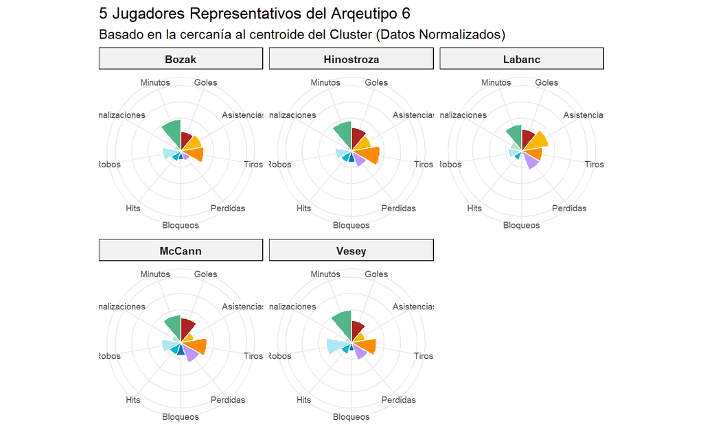

```r
# Seleccionamos solo las variables de juego + el nombre
top5_6 <- data_norm_global %>%
  filter(Cluster_Final == "6")


top5_6$distancia_centroide <- apply(data_cluster6[, pcs_nombres], 1, function(fila) {sqrt(sum((fila - centroide_c6)^2))})

jugadores_representativos_long <-  top5_6 %>%
  arrange(distancia_centroide) %>%
  head(5)  %>%
  select(lastName, goals, assists, shots, blocked, takeaways, hits, giveaways, timeOnIce, penaltyMinutes) %>%
  rename(Goles = goals, Asistencias = assists, Tiros = shots,
          Robos = takeaways, Perdidas = giveaways, Hits = hits, Bloqueos = blocked,  Penalizaciones = penaltyMinutes, Minutos = timeOnIce) %>%
  pivot_longer(-lastName, names_to = "Variable", values_to = "Valor") %>%
  mutate(Variable = factor(Variable, levels = orden_logico))

ggplot(jugadores_representativos_long, aes(x = Variable, y = Valor, fill = Variable)) +
  geom_bar(stat = "identity", width = 1, color = "white") +
  coord_polar() +
  facet_wrap(~ lastName) + # Esto crea los 5 mini-gráficos
  scale_fill_manual(values = mis_colores) +
  scale_y_continuous(limits = c(0, 1)) +
  theme_minimal() +
  labs(
    title = "5 Jugadores Representativos del Arqeutipo 6",
    subtitle = "Basado en la cercanía al centroide del Cluster (Datos Normalizados)",
    x = NULL, y = NULL) +
  theme(
    axis.text.x = element_text(size = 7, angle = 0),
    axis.text.y = element_blank(),
    strip.background = element_rect(fill = "gray95"),
    strip.text = element_text(face = "bold"),
    legend.position = "none"
  )
```

En estos jugadores se aprecia una morfología táctica muy equilibrada que justifica su rol de aportar profunidad al equipo. A diferencia de las superestrellas, sus gráficos de rosas muestran una distribución armónica donde destacan valores sólidos en Goles, Asistencias y Robos, pero sin los picos de volumen extremo de las primeras líneas.

Esta visualización pone nombre y apellidos a la clase media de la NHL: jugadores polivalentes capaces de cumplir en múltiples situaciones de juego. Hombres como **Tyler Bozak**, **Jared McCann** o **Jimmy Vesey** personifican esta estabilidad; son patinadores que garantizan que el nivel competitivo no decaiga durante las rotaciones, aportando un peligro secundario que suele ser el factor diferencial en las rachas ganadoras de las franquicias.

## ANÁLISIS DE JUGADORES POR CLÚSTER

Tras haber definido matemáticamente la identidad de nuestros seis arquetipos mediante las Componentes Principales y validado su perfil táctico a través de los gráficos de rosas, el siguiente paso es confrontar este modelo con la estructura tradicional de la NHL.

El objetivo de este apartado es responder a una pregunta fundamental: ¿Cómo se distribuyen las posiciones oficiales clásicas (Centro, Alero Izquierdo, Alero Derecho y Defensa) dentro de nuestras nuevas categorías basadas en el rendimiento?

A través del análisis porcentual y la normalización cruzada de los datos, evaluaremos si las etiquetas que las franquicias asignan a sus jugadores dictan realmente su estilo de juego, o si, por el contrario, nuestros arquetipos logran aislar funciones tácticas que trascienden la simple posición del patinador.

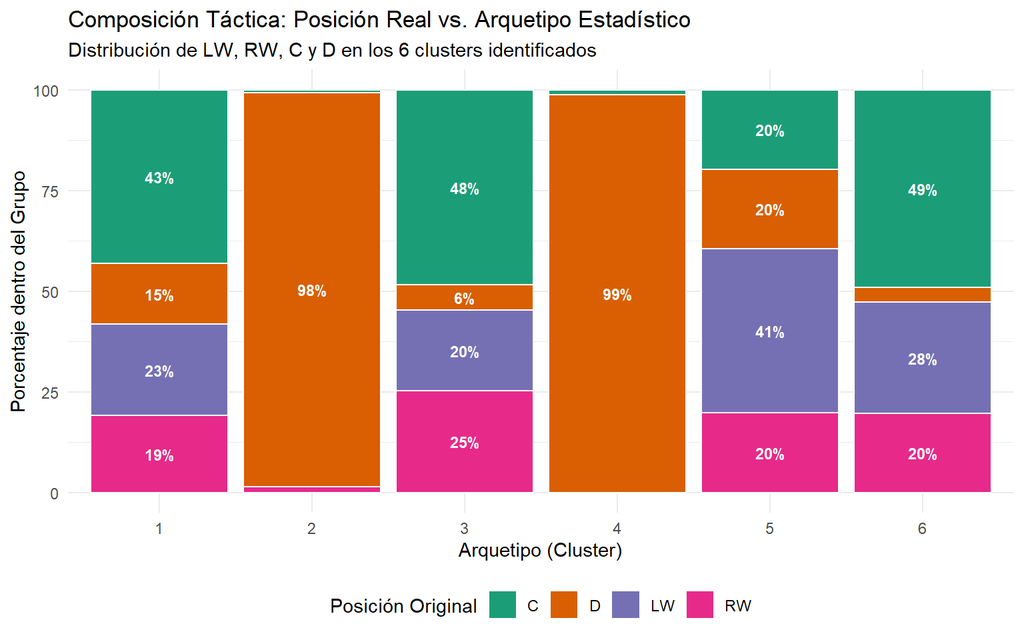

```r
# 1. Calculamos los porcentajes de LW, RW, C y D por cada uno de tus 6 clusters
posicion_por_cluster <- data_con_clusters %>%
  group_by(Cluster_Final, primaryPosition) %>%
  filter(primaryPosition %in% c("C", "LW", "RW", "D")) %>% # Filtramos posiciones estándar
  tally() %>%
  group_by(Cluster_Final) %>%
  mutate(porcentaje = (n / sum(n)) * 100)

# 2. Gráfico de barras apiladas al 100%
ggplot(posicion_por_cluster, aes(x = Cluster_Final, y = porcentaje, fill = primaryPosition)) +
  geom_bar(stat = "identity", position = "stack", color = "white") +
  geom_text(aes(label = ifelse(porcentaje > 5, paste0(round(porcentaje, 0), "%"), "")),
            position = position_stack(vjust = 0.5), size = 3, color = "white", fontface = "bold") +
  scale_fill_manual(values = c("C" = "#1b9e77", "D" = "#d95f02", "LW" = "#7570b3", "RW" = "#e7298a")) +
  labs(title = "Composición Táctica: Posición Real vs. Arquetipo Estadístico",
       subtitle = "Distribución de LW, RW, C y D en los 6 clusters identificados",
       x = "Arquetipo (Cluster)",
       y = "Porcentaje dentro del Grupo",
       fill = "Posición Original") +
  theme_minimal() +
  theme(legend.position = "bottom")
```

Vamos a normalizar los datos por posicion para eliminar el sesgo de frecuencia derivado de la mayor abundancia de delanteros en la liga, permitiendo que el análisis refleje la especialización táctica real y no el simple volumen de jugadores.

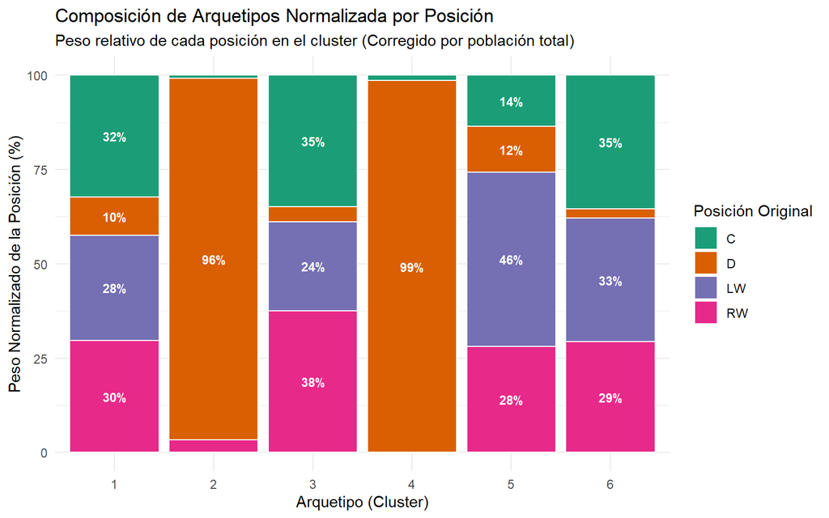

```r
# 1. Normalizamos
posicion_intercambiada_norm <- data_con_clusters %>%
  filter(primaryPosition %in% c("C", "LW", "RW", "D")) %>%
  group_by(primaryPosition, Cluster_Final) %>%
  tally() %>%
  # Paso A: Normalizamos por POSICIÓN
  group_by(primaryPosition) %>%
  mutate(peso_relativo = n / sum(n)) %>%
  # Paso B: Normalizamos por CLUSTER para que la barra sume 100%
  group_by(Cluster_Final) %>%
  mutate(pct_ajustado = (peso_relativo / sum(peso_relativo)) * 100)

# 2. Gráfico con Cluster en el eje X y Posición en la Leyenda
ggplot(posicion_intercambiada_norm, aes(x = Cluster_Final, y = pct_ajustado, fill = primaryPosition)) +
  geom_bar(stat = "identity", position = "stack", color = "white") +
  geom_text(aes(label = ifelse(pct_ajustado > 5, paste0(round(pct_ajustado, 0), "%"), "")),
            position = position_stack(vjust = 0.5), size = 3, color = "white", fontface = "bold") +
  scale_fill_manual(values = c("C" = "#1b9e77", "D" = "#d95f02", "LW" = "#7570b3", "RW" = "#e7298a")) +
  labs(title = "Composición de Arquetipos Normalizada por Posición",
       subtitle = "Peso relativo de cada posición en el cluster (Corregido por población total)",
       x = "Arquetipo (Cluster)",
       y = "Peso Normalizado de la Posición (%)",
       fill = "Posición Original") +
  theme_minimal() +
  theme(legend.position = "right")
```

Tal y como se ha diferenciado cada uno de los clústers, la siguiente gráfica muestra las zonas de la pista donde mayor influencia tiene cada arquetipo de jugador:

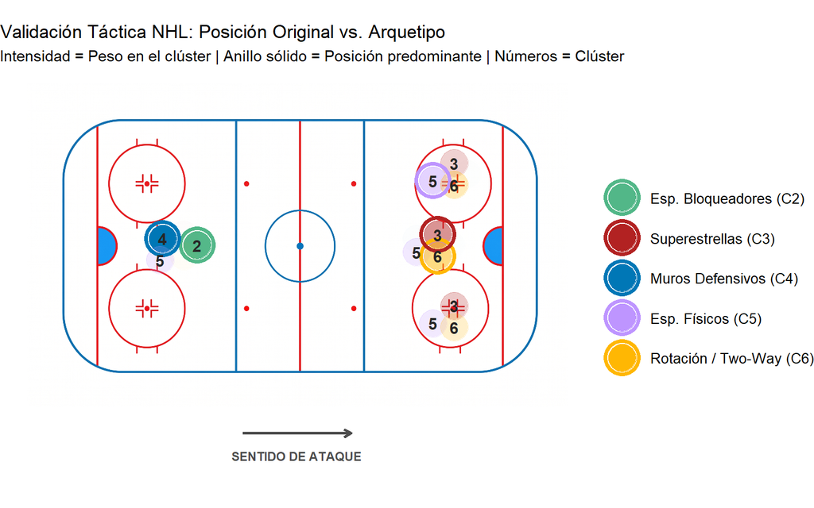

```r
# Colores
mis_colores <- c(
  "Esp. Bloqueadores (C2)" = "#52B788",
  "Superestrellas (C3)"    = "#B22222",
  "Muros Defensivos (C4)"  = "#0077B6",
  "Esp. Físicos (C5)"      = "#BE95FF",
  "Rotación / Two-Way (C6)"= "#FFB703"
)

mapa_detalle <- data.frame(
  Arquetipo = names(mis_colores),
  D =  c(0.98, 0.01, 0.99, 0.20, 0.03),
  C =  c(0.01, 0.48, 0.01, 0.20, 0.49),
  LW = c(0.01, 0.20, 0.00, 0.41, 0.28),
  RW = c(0.00, 0.25, 0.00, 0.20, 0.20)
) %>%
  pivot_longer(cols = c(D, C, LW, RW), names_to = "Posicion", values_to = "Porcentaje")

mapa_detalle$Arquetipo <- factor(mapa_detalle$Arquetipo, levels = names(mis_colores))

predominantes_final <- mapa_detalle %>%
  group_by(Arquetipo) %>%
  filter(Porcentaje == max(Porcentaje)) %>%
  ungroup()

# Coordenadas con ajuste manual y filtro de números
coords <- data.frame(
  Posicion = c("D", "C", "LW", "RW"),
  x_base = c(28, 75, 78, 78),
  y_base = c(50, 50, 72, 28)
)

mapa_final <- merge(mapa_detalle, coords, by = "Posicion") %>%
  mutate(
    id_num = as.numeric(gsub(".*C(\\d+).*", "\\1", Arquetipo)),
    angulo = (id_num - 2) * (2 * pi / 5),
    radio = 3.5,
    x_final = x_base + cos(angulo) * radio,
    y_final = y_base + sin(angulo) * radio,

    # Ajuste manual antisolape para D-5
    y_final = ifelse(Posicion == "D" & id_num == 5, y_final - 2.5, y_final),
    x_final = ifelse(Posicion == "D" & id_num == 5, x_final - 0.5, x_final),

    # FILTRO: Borramos los números que flotan sobre círculos casi invisibles
    etiqueta_num = case_when(
      Posicion == "D" & id_num %in% c(3, 6) ~ "",
      Posicion %in% c("LW", "RW", "C") & id_num %in% c(2, 4) ~ "",
      TRUE ~ as.character(id_num) # El resto se queda igual
    )
  )

predominantes_final <- merge(predominantes_final,
                             mapa_final[, c("Arquetipo", "Posicion", "x_final", "y_final", "id_num")],
                             by = c("Arquetipo", "Posicion"))

# ---------------------------------------------------------
# CARGAR LA IMAGEN DE FONDO
# ---------------------------------------------------------
img <- readPNG("pista.png") # O readJPG("pista.jpg")
g <- rasterGrob(img, width = unit(1, "npc"), height = unit(1, "npc"), interpolate = TRUE)

# Gráfico Final
ggplot() +
  annotation_custom(g, xmin = 0, xmax = 100, ymin = 0, ymax = 100) +

  # Flecha inferior
  annotate("segment", x = 40, xend = 60, y = -8, yend = -8,
           color = "gray30", linewidth = 1, arrow = arrow(length = unit(0.2, "cm"))) +
  annotate("text", x = 50, y = -15, label = "SENTIDO DE ATAQUE", fontface = "bold", size = 3, color = "gray30") +

  # Capa 1: Puntos de color con transparencia
  geom_point(data = mapa_final, aes(x = x_final, y = y_final, color = Arquetipo, alpha = (Porcentaje+0.2)), size = 9) +

  # Capa 2: Anillo sólido (Posición predominante)
  geom_point(data = predominantes_final, aes(x = x_final, y = y_final, color = Arquetipo),
             shape = 21, size = 10, stroke = 2, fill = "transparent") +

  # Capa 3: NÚMEROS (Usando la nueva variable filtrada 'etiqueta_num')
  geom_text(data = mapa_final, aes(x = x_final, y = y_final, label = etiqueta_num),
            color = "gray15", fontface = "bold", size = 4) +

  scale_color_manual(values = mis_colores) +
  scale_alpha_continuous(range = c(0, 1), guide = "none") +

  coord_fixed(xlim = c(0, 100), ylim = c(-20, 100), ratio = 0.6) +

  theme_void() +
  theme(legend.position = "right",
        legend.title = element_blank(),
        legend.text = element_text(size = 10)) + # Reducimos un poco la fuente si es necesario) +
  labs(title = "Validación Táctica NHL: Posición Original vs. Arquetipo",
       subtitle = "Intensidad = Peso en el clúster | Anillo sólido = Posición predominante | Números = Clúster")
```

# 4. ANÁLISIS ESTRUCTURAL DE LOS EQUIPOS

Primero debemos agregar las tablas necesarias para obtener la información de que jugador juega en cada equipo (team_id y player_id) con la tabla cargada previamente que contiene los datos obtenidos durante el estudio.

```r
# 1. Crear el mapeo de equipo filtrando por la temporada en la tabla 'game'
suppressWarnings({
mapping_equipo_1819 <- game_skater_stats %>%
  inner_join(games %>% select(game_id, season), by = "game_id") %>%
  filter(season == 20182019) %>%
  group_by(player_id) %>%
  summarise(team_id = last(team_id)) %>%
  # Traemos los nombres legibles
  inner_join(team_info %>% select(team_id, teamName), by = "team_id") %>%
  inner_join(player_info %>% select(player_id, firstName, lastName), by = "player_id") %>%
  select(firstName, lastName, teamName, team_id)

# 2. Unir con los resultados de clusters
# Usamos select para quedarnos solo con lo que interesa de los clusters
data_jugadores_equipo_cluster <- data_jugadores_con_clusters %>%
  select(firstName, lastName, Cluster_Final) %>%
  inner_join(mapping_equipo_1819, by = c("firstName", "lastName"))
})
```

Antes de todo, vamos a visualizar que porcentaje de cada arquetipo hay en la liga.

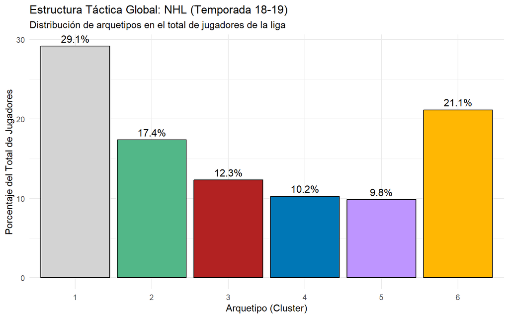

```r
# 1. Preparamos los datos de toda la liga
liga_plot <- data_jugadores_equipo_cluster %>%
  group_by(Cluster_Final) %>%
  tally() %>%
  mutate(pct = n / sum(n) * 100)

# 2. Generamos el gráfico
ggplot(liga_plot, aes(x = Cluster_Final, y = pct, fill = Cluster_Final)) +
  geom_bar(stat = "identity", color = "black") +
  geom_text(aes(label = paste0(round(pct, 1), "%")), vjust = -0.5, size = 4) +
  scale_fill_manual(values = colores_clusters) + # Paleta de 6 colores
  theme_minimal() +
  labs(title = "Estructura Táctica Global: NHL (Temporada 18-19)",
       subtitle = "Distribución de arquetipos en el total de jugadores de la liga",
       x = "Arquetipo (Cluster)",
       y = "Porcentaje del Total de Jugadores",
       fill = "Cluster") +
  theme(legend.position = "none")
```

Una vez conocida la composición de la liga en base a los arquetipos definidos, se puede analizar el perfil de los equipos. Tenemos una clasificación de los jugadores desde un punto de vista táctico. Sin embargo, en el hockey no juegan individuos, juegan líneas de 3 atacantes y parejas de 2 defensas. Por eso, resulta de gran interés saber qué diferencia a un equipo campeón del resto o qué combinaciones de arquetipos son más beneficiosas para el equipo y cuáles son un desastre táctico.

Para ello, primero se debe comprender como funciona el sistema de clasificación en la NHL. Este, está dividido en dos fases:

- La Temporada Regular (President’s Trophy): Los 31 equipos compiten en 82 partidos. El éxito aquí se mide por puntos: se otorgan 2 puntos por victoria, 1 por derrota en prórroga o shootout, y 0 por derrota en tiempo reglamentario. El equipo con más puntos al final de esta fase gana el President’s Trophy, siendo el equipo más sólido y constante.
- Los Playoffs (Stanley Cup): Los 16 mejores equipos clasifican a las eliminatorias directas. Aquí el éxito es binario: ganar o ser eliminado. El campeón final se alza con la Stanley Cup.